# Converged Route A magnitudes for catalogs v4.1 and v5.1

Decision D-B091 (PI, 2026-11-25 10:24). Branch `analysis/mag-converged`; large outputs in `/wd1/mdenolle_data/magnitude_converged`. Only the phase19 solver changed: amplitudes, SNR cut, station epochs, the Hutton-Boore distance term, the 150 km pick selection, the 4-MAD rejection, the ComCat ML anchors, the Mw switch at 4.5 and the Mw_cal rule are those of the stored runs.

**Independent verification.** A separate verifier re-derived the converged magnitudes (scripts and outputs in `/wd1/mdenolle_data/magnitude_converged/verify/`) and found them fit to replace the paper's magnitudes. Its checks: the solution is the true minimum, it is set by the data and not by the damping (damping 1e-4 changes ML by at most 0.001, damping 1e-2 by 0.026 at the 99th percentile), and the anchor test is not circular (offset from half of the anchors, gap measured on the other half: offshore +0.116 stored, +0.009 converged, in 99.8% of 500 splits closer to zero). Its must-fix items are resolved here: one gauge row with a null-direction check (section 1b); the text that said two gauge rows fix the P-S difference is corrected; the isolated term no longer appears in the station-term tables.

## 1. Solver change and convergence proof

phase19 fits station ML = M_i + C_jp to the Hutton-Boore station magnitudes within 150 km, with damping 1e-3 and gauge rows of weight 1000 (section 1b for the gauge). The stored runs solved it with LSQR stopped at 3000 iterations (istop 7). LSQR is slow on this system for two reasons. First, the column norms range from 1 (an event with one pick) to 130 (a station-phase term with 16,876 picks), and the gauge rows have weight 1000. Second, moving a whole deployment against its events changes the misfit little per unknown: the eigenvalue of that mode is the deployment's stiffness divided by its number of terms plus events (X9 0.25, Z5 2013 0.48, OO 2014 0.009, against 1.5e4 at the top of the data spectrum). Starting from zero station terms, LSQR resolves these modes last. Until it does, the large site terms of sediment-covered ocean-bottom stations stay in the event terms, so offshore ML comes out too high.

The new default, `phase19_solver.solve(method='exact')`, eliminates the event terms (their block of the normal equations is diagonal). The 1,337 x 1,337 Schur complement of the station terms is solved by a symmetric eigendecomposition, and two refinement steps follow on the full sparse system. It raises `NotConverged` unless the last refinement step is below 1e-8 and the relative normal-equation residual is below 1e-10, or unless the gauge rows equal the null directions (section 1b). `--solver lsqr` runs a column-scaled LSQR with atol = btol = 1e-12 and fails unless istop is 1 or 2. `--solver legacy3000` reproduces the stored runs.

| run | solver | istop | itn | r_norm | normal_res_rel | anchor_offset | n_anchors | anchor_std | mapped_intercept | mapped_slope | mapped_std | mw_cal_near | mw_cal_mapped | M_type_ML | M_type_Mw | M_type_Mw_cal |
| --- | --- | --- | --- | --- | --- | --- | --- | --- | --- | --- | --- | --- | --- | --- | --- | --- |
| v4.1 converged | exact |  |  | 268.921 | 0.000 | 0.356 | 3,416 | 0.174 | -0.295 | 1.014 | 0.602 | 0.187 | 1.420 | 130,660 | 80 | 27 |
| v4.1 legacy rerun | legacy3000 | 7.000 | 3000.000 | 269.267 | 0.000 | 0.406 | 3,416 | 0.207 | -0.349 | 1.146 | 0.755 | 0.056 | 0.995 | 130,655 | 80 | 32 |
| v5.1 converged | exact |  |  | 267.902 | 0.000 | 0.343 | 3,414 | 0.175 | -0.289 | 0.999 | 0.651 | 0.169 | 1.507 | 130,246 | 75 | 25 |

Exact-solver diagnostics (both passes, v4.1 and v5.1, one gauge row): last refinement step 5e-15 to 6e-14, relative normal-equation residual 5e-14 to 3e-13; in every pass 1 connected piece, 1 numerical null direction, 1 gauge row. The full phase19 run with `--solver lsqr` (column-scaled, istop 2 after 238 and 240 iterations) gives the same v4.1 output file as the exact run (largest difference 0.000). Independent check on the first version (two-row system, v4.1 first pass): a sparse LU factorisation of the full 162,515 x 162,515 normal equations differs by at most 5.4e-7.

### Thread count

phase19 'near' ML of v4.1 (both passes and the anchor offset) in separate processes with 1 and 12 BLAS threads:

| solver | n_events_t1 | n_events_t12 | n_common | max_abs | p99_abs | median_abs | share_gt_1e4 | share_gt_0p1 |
| --- | --- | --- | --- | --- | --- | --- | --- | --- |
| exact | 127,247 | 127,247 | 127,247 | 6.22e-15 | 5.44e-15 | 6.66e-16 | 0 | 0 |
| legacy3000 | 127,251 | 127,251 | 127,250 | 0.864 | 0.075 | 0.0105 | 0.988 | 0.000236 |

### How far LSQR stops from the minimum

LSQR on the final v4.1 pick set, stopped at increasing iteration counts, against the exact solution (ML with the anchor offset recomputed, near events):

| solver | iter_lim | istop | itn | max_abs | p99_abs | median_abs | normal_res_rel |
| --- | --- | --- | --- | --- | --- | --- | --- |
| LSQR (phase19 settings, stored system: two gauge rows) | 500 | 7 | 500 | 5.42 | 1.45 | 0.96 | 1.33e-05 |
| LSQR (phase19 settings, stored system: two gauge rows) | 1,000 | 7 | 1,000 | 6.28 | 1.23 | 0.855 | 7.07e-06 |
| LSQR (phase19 settings, stored system: two gauge rows) | 2,000 | 7 | 2,000 | 1.88 | 0.925 | 0.349 | 4.74e-06 |
| LSQR (phase19 settings, stored system: two gauge rows) | 3,000 | 7 | 3,000 | 1.45 | 0.655 | 0.0688 | 4.18e-06 |
| LSQR (phase19 settings, stored system: two gauge rows) | 4,000 | 7 | 4,000 | 0.373 | 0.105 | 0.0169 | 2.22e-06 |
| LSQR (phase19 settings, stored system: two gauge rows) | 5,000 | 2 | 4,600 | 0.144 | 0.0636 | 0.000738 | 2.53e-07 |
| LSQR (phase19 settings, stored system: two gauge rows) | 6,000 | 2 | 4,600 | 0.144 | 0.0636 | 0.000738 | 2.53e-07 |
| LSQR (phase19 settings, stored system: two gauge rows) | 8,000 | 2 | 4,600 | 0.144 | 0.0636 | 0.000738 | 2.53e-07 |
| LSQR (phase19 settings, stored system: two gauge rows) | 12,000 | 2 | 4,600 | 0.144 | 0.0636 | 0.000738 | 2.53e-07 |
| LSQR (phase19 tolerances, new system: one gauge row) | 1,000 | 7 | 1,000 | 1.01 | 1.01 | 0.62 | 0.000194 |
| LSQR (phase19 tolerances, new system: one gauge row) | 2,000 | 7 | 2,000 | 0.666 | 0.294 | 0.0146 | 2.43e-06 |
| LSQR (phase19 tolerances, new system: one gauge row) | 3,000 | 7 | 3,000 | 0.226 | 0.225 | 0.00385 | 7.12e-07 |
| LSQR (phase19 tolerances, new system: one gauge row) | 4,000 | 2 | 3,097 | 0.224 | 0.223 | 0.00419 | 2.85e-07 |
| LSQR (phase19 tolerances, new system: one gauge row) | 6,000 | 2 | 3,097 | 0.224 | 0.223 | 0.00419 | 2.85e-07 |
| LSQR column-scaled (new system) | 50 | 7 | 50 | 2.78 | 0.149 | 0.047 | 0.00124 |
| LSQR column-scaled (new system) | 100 | 7 | 100 | 0.176 | 0.0581 | 0.0228 | 9.21e-07 |
| LSQR column-scaled (new system) | 200 | 7 | 200 | 0.0132 | 0.0132 | 0.000599 | 1.36e-07 |
| LSQR column-scaled (new system) | 300 | 2 | 252 | 1.64e-08 | 5.55e-10 | 3.45e-10 | 3.03e-12 |
| LSQR column-scaled (new system) | 400 | 2 | 252 | 1.64e-08 | 5.55e-10 | 3.45e-10 | 3.03e-12 |

With the phase19 tolerances LSQR reaches istop 2 after 4,600 iterations and is then still 0.064 from the minimum at the 99th percentile (largest 0.14). istop 2 bounds the gradient, not the error: in a soft direction the error is the gradient divided by a small eigenvalue. The D-B091 check (4,863 iterations on the stored v5.1 pick set) was therefore close, but not exact (section 4).

The same tolerances on the new one-row system stop with istop 2 after 3,097 iterations, 0.22 from the minimum at the 99th percentile: the stopping test is the problem, not the gauge. The column-scaled LSQR reaches the minimum to 1e-8 in a few hundred iterations.

### 1b. Gauge rows and null directions (verifier must-fix 1)

The data fix every M_i + C_jp but not a common shift: on each connected piece of the event / station-phase graph, all event terms +delta and all station terms -delta leave the misfit unchanged. The gauge needs one row per such null direction; any further row constrains the fit. The stored runs, and the first version of this work, used two rows (sum of the P terms = 0, sum of the S terms = 0). The graph had two pieces: the main network and one isolated S term, 7D.J35C@2013-08-09|S (9 picks on 9 one-pick events). The S row was absorbed by that term, which ended at C = -303 (v4.1) and -295 (v5.1); stored legacy runs -255 and -234. The two rows therefore fixed the two null directions, and the P - S level difference of the main network stayed free (mean S term - mean P term +0.454). The earlier text of this report said that the two rows fix the P - S difference; that was wrong. Without the isolated term, though, the two rows would have forced mean S = mean P: the misfit rises by about 2,900 and regional ML moves by up to -0.22. The convergence test of the solver does not see this, because the constrained problem is solved exactly too.

Fix: picks not linked to the main network are dropped before each pass (`main_component()`; their events have fewer than 3 picks, so no ML is lost). ONE gauge row is used (sum of the P terms = 0, which keeps the P terms and the main-network S terms of the previous solution). `check_gauge()` counts the null directions from the graph (connected pieces) and numerically (eigenvalues of the reduced system below 1e-9 of the largest). It raises NotConverged unless both equal the number of gauge rows and the gauge rows are not orthogonal to the null space. The anchor offset absorbs any single gauge row, so ML does not depend on which one is chosen. The isolated term no longer appears in the converged station-term tables. The stored `phase19_station_terms_v51.csv` still lists it (C about -234); that value is a gauge artefact and should be ignored.

Design test on the final v4.1 pick set (exact solver; the 9 isolated picks added back where kept):

| design | gauge_rows | connected_pieces | null_directions | check_passes | misfit | meanS_minus_meanP | isolated_term | max_abs_dML_vs_stored_design | dML_Mendocino | dML_Offshore forearc | dML_Gorda | dML_Blanco | dML_Axial | dML_Explorer | dML_Puget/Georgia |
| --- | --- | --- | --- | --- | --- | --- | --- | --- | --- | --- | --- | --- | --- | --- | --- |
| stored design: two rows (sum P, sum S), isolated term kept | 2 | 2 | 2 | True | 72318.587 | 0.454 | -303.345 | 0.000 | 0.000 | 0.000 | 0.000 | 0.000 | 0.000 | 0.000 | 0.000 |
| new: one row (sum P), isolated term dropped | 1 | 1 | 1 | True | 72318.587 | 0.454 |  | 0.002 | 0.000 | 0.000 | 0.000 | 0.000 | 0.000 | -0.000 | -0.000 |
| one row, isolated term kept | 1 | 2 | 2 | False | 72318.587 | 0.454 | 2.738 | 0.002 | 0.000 | 0.000 | 0.000 | 0.000 | 0.000 | -0.000 | -0.000 |
| two rows, isolated term dropped | 2 | 1 | 1 | False | 75256.373 | 0.000 |  | 4.655 | -0.222 | -0.217 | -0.212 | -0.124 | -0.155 | 0.123 | 0.017 |

The new full chain (both passes, rejection, anchor offset) against the previous converged run with two rows, unrounded near-event ML:

| catalog | n_prev | n_new | n_common | max_abs | median |
| --- | --- | --- | --- | --- | --- |
| v4.1 | 127,247 | 127,247 | 127,247 | 1.45e-03 | 2.10e-05 |
| v5.1 | 126,843 | 126,843 | 126,843 | 1.53e-03 | 4.30e-05 |

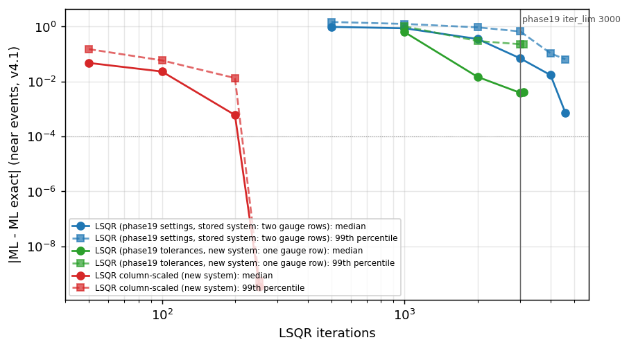

LSQR error against iterations (v4.1, near events), each against the exact solution of its own system. Blue: the stored system with the phase19 settings. Green: the new one-row system with the same tolerances. Red: the column-scaled LSQR.

## 2. The gauge: how each ocean-bottom deployment is tied to the land network

Groups: every seafloor station-epoch, grouped by network and deployment year (7D = Cascadia Initiative years Y1-Y4); everything on land is the reference. Per group, on the final pick set of the converged run: **n_events_with_land** = events with picks on the group and on land stations; **n_events_with_other_obs** = events shared with another ocean-bottom group; **n_anchors** = ComCat ML anchors among its near events (**dominated**: anchors with at least half of their picks on the group); **stiffness** k = misfit increase per delta^2 when all its terms move by +delta and the events are re-fitted (the Schur complement; equal to the sum over events of n_G n_other / n, an effective number of tie picks); **se_level** = formal standard error of the mean term of the group minus the mean land term (sigma = 0.245, from the full inverse of the reduced system); **dphi_opt_0.5** and **dphi_naive_0.5** = misfit increase for delta = 0.5 with the events re-fitted, and with every event that has a pick on the group moved by -delta (the +delta/-delta test; total misfit 72,319); **dC_minus_land** = change of the mean term (converged minus stored) relative to the land mean; **dML_dominated** = median ML change of the events with at least half of their picks on the group; **anchor_gap** = median ML - ComCat ML of the dominated anchors.

### v4.1, ocean-bottom deployments

| group | n_terms | n_picks | n_events | n_events_with_land | n_events_with_other_obs | n_anchors | n_anchors_dominated | stiffness | rigid_mode_eig | se_level | dphi_opt_0.5 | dphi_naive_0.5 | dC_minus_land | dML_dominated | anchor_gap_unconv | anchor_gap_conv | main_region |
| --- | --- | --- | --- | --- | --- | --- | --- | --- | --- | --- | --- | --- | --- | --- | --- | --- | --- |
| 7A 2010 | 9 | 188 | 74 | 51 | 3 | 1 | 0 | 74.897 | 0.902 | 0.032 | 18.724 | 80.250 | -0.010 | -0.014 |  |  | Explorer |
| 7D Y1 (2011-12) | 40 | 2,368 | 1,212 | 219 | 215 | 18 | 0 | 405.657 | 0.324 | 0.030 | 101.414 | 453.998 | -0.303 | 0.289 |  |  | JdF ridge/plate |
| 7D Y2 (2012-13) | 98 | 32,962 | 9,451 | 2,615 | 3,900 | 44 | 24 | 12101.530 | 1.267 | 0.010 | 3025.383 | 14493.003 | 0.243 | -0.179 | 0.298 | 0.030 | Mendocino |
| 7D Y3 (2013-14) | 55 | 7,819 | 4,018 | 303 | 2,313 | 25 | 1 | 2506.662 | 0.615 | 0.021 | 626.665 | 3722.250 | -0.075 | -0.263 | 0.501 | 0.138 | JdF ridge/plate |
| 7D Y4 (2014-15) | 97 | 68,583 | 16,899 | 5,753 | 9,009 | 78 | 43 | 27520.139 | 1.619 | 0.009 | 6880.035 | 18837.760 | 0.113 | -0.166 | 0.172 | 0.016 | Gorda |
| NV 2010 | 7 | 625 | 471 | 54 | 312 | 1 | 0 | 255.965 | 0.535 | 0.042 | 63.991 | 207.000 | -0.223 | 0.139 |  |  | Explorer |
| NV 2011 | 2 | 210 | 166 | 2 | 148 | 0 | 0 | 118.532 | 0.706 | 0.040 | 29.633 | 91.000 | -0.221 | 0.183 |  |  | Endeavour |
| NV 2013 | 6 | 602 | 488 | 78 | 417 | 3 | 0 | 366.862 | 0.743 | 0.027 | 91.716 | 389.000 | 0.061 | -0.172 |  |  | JdF ridge/plate |
| NV 2014 | 4 | 189 | 125 | 2 | 13 | 0 | 0 | 9.750 | 0.076 | 0.085 | 2.438 | 4.750 | -0.028 | 0.007 |  |  | JdF ridge/plate |
| OO 2014 | 26 | 112,078 | 22,053 | 66 | 120 | 13 | 4 | 194.429 | 0.009 | 0.028 | 48.607 | 170.254 | -0.043 | 0.073 | 0.388 | 0.385 | Axial |
| X9 2012 | 60 | 121,591 | 21,581 | 4 | 4,294 | 12 | 9 | 5323.663 | 0.246 | 0.016 | 1330.916 | 1766.266 | 0.633 | -0.668 | 0.873 | 0.231 | Blanco |
| Z5 2013 | 50 | 55,439 | 14,958 | 2,529 | 2,477 | 82 | 38 | 7136.365 | 0.475 | 0.011 | 1784.091 | 7989.514 | 0.362 | -0.591 | 0.221 | -0.088 | Blanco |
| Z5 2014 | 24 | 36,387 | 13,132 | 832 | 8,464 | 52 | 13 | 9136.718 | 0.695 | 0.012 | 2284.180 | 10180.514 | 0.042 | 0.014 | -0.120 | -0.128 | Blanco |

### v5.1, ocean-bottom deployments

| group | n_terms | n_picks | n_events | n_events_with_land | n_events_with_other_obs | n_anchors | n_anchors_dominated | stiffness | rigid_mode_eig | se_level | dphi_opt_0.5 | dphi_naive_0.5 | dC_minus_land | dML_dominated | anchor_gap_unconv | anchor_gap_conv | main_region |
| --- | --- | --- | --- | --- | --- | --- | --- | --- | --- | --- | --- | --- | --- | --- | --- | --- | --- |
| 7A 2010 | 8 | 167 | 68 | 50 | 1 | 1 | 0 | 68.550 | 0.902 | 0.033 | 17.137 | 77.750 | 0.058 | -0.104 |  |  | Explorer |
| 7D Y1 (2011-12) | 39 | 2,401 | 1,213 | 184 | 213 | 17 | 0 | 376.395 | 0.301 | 0.033 | 94.099 | 435.498 | -0.313 | 0.303 |  |  | JdF ridge/plate |
| 7D Y2 (2012-13) | 99 | 33,037 | 9,458 | 2,586 | 3,897 | 46 | 24 | 12036.105 | 1.259 | 0.010 | 3009.026 | 14472.253 | 0.309 | -0.299 | 0.415 | 0.009 | Mendocino |
| 7D Y3 (2013-14) | 54 | 7,818 | 4,011 | 294 | 2,308 | 25 | 1 | 2490.284 | 0.613 | 0.020 | 622.571 | 3705.751 | -0.237 | -0.524 | 0.636 | 0.111 | JdF ridge/plate |
| 7D Y4 (2014-15) | 96 | 68,690 | 16,897 | 5,730 | 8,992 | 78 | 43 | 27407.984 | 1.613 | 0.009 | 6851.996 | 18748.511 | 0.210 | -0.287 | 0.291 | 0.026 | Gorda |
| NV 2010 | 7 | 628 | 476 | 24 | 309 | 1 | 0 | 244.463 | 0.506 | 0.046 | 61.116 | 191.750 | 0.077 | 0.042 |  |  | Explorer |
| NV 2011 | 2 | 211 | 167 | 0 | 149 | 0 | 0 | 117.015 | 0.692 | 0.045 | 29.254 | 89.000 | -0.215 | 0.153 |  |  | Endeavour |
| NV 2013 | 6 | 594 | 479 | 66 | 417 | 3 | 0 | 359.809 | 0.742 | 0.029 | 89.952 | 380.250 | 0.208 | -0.440 |  |  | JdF ridge/plate |
| NV 2014 | 4 | 199 | 127 | 0 | 12 | 0 | 0 | 8.250 | 0.063 | 0.091 | 2.062 | 4.000 | -0.293 | 0.262 |  |  | JdF ridge/plate |
| OO 2014 | 26 | 111,062 | 21,892 | 71 | 120 | 13 | 4 | 199.621 | 0.009 | 0.028 | 49.905 | 173.499 | 0.025 | -0.060 | 0.478 | 0.400 | Axial |
| X9 2012 | 60 | 122,024 | 21,585 | 3 | 4,294 | 12 | 9 | 5320.614 | 0.246 | 0.016 | 1330.153 | 1758.017 | 0.649 | -0.711 | 0.932 | 0.251 | Blanco |
| Z5 2013 | 50 | 55,562 | 14,968 | 2,520 | 2,469 | 82 | 38 | 7081.115 | 0.471 | 0.011 | 1770.279 | 7849.764 | 0.439 | -0.689 | 0.362 | -0.073 | Blanco |
| Z5 2014 | 24 | 36,393 | 13,121 | 803 | 8,448 | 52 | 13 | 9103.989 | 0.693 | 0.012 | 2275.997 | 10010.514 | 0.171 | -0.176 | 0.089 | -0.099 | Blanco |

### Land networks, each against the rest of the land network (networks with at least 1,000 picks)

Here 'land' in the column names means the land terms outside the network.

### v4.1, land networks

| group | n_terms | n_picks | n_events | n_events_with_land | n_events_with_other_obs | n_anchors | n_anchors_dominated | stiffness | rigid_mode_eig | se_level | dphi_opt_0.5 | dphi_naive_0.5 | dC_minus_land | dML_dominated | anchor_gap_unconv | anchor_gap_conv | main_region |
| --- | --- | --- | --- | --- | --- | --- | --- | --- | --- | --- | --- | --- | --- | --- | --- | --- | --- |
| BK | 7 | 10,538 | 7,794 | 7,527 | 3,753 | 105 | 0 | 9024.951 | 1.157 | 0.017 | 2256.238 | 30327.010 | 0.100 | -0.168 |  |  | Offshore forearc |
| C8 | 15 | 2,174 | 874 | 858 | 3 | 128 | 0 | 1770.656 | 1.992 | 0.013 | 442.664 | 4360.999 | -0.054 | 0.019 |  |  | Puget/Georgia |
| CC | 44 | 40,332 | 11,938 | 11,573 | 0 | 1,053 | 2 | 26383.310 | 2.202 | 0.005 | 6595.828 | 63902.999 | -0.016 | 0.007 | -0.997 | -1.043 | Cascades |
| CN | 60 | 58,459 | 11,889 | 8,473 | 537 | 1,097 | 63 | 21023.050 | 1.759 | 0.005 | 5255.763 | 22537.255 | -0.048 | 0.018 | -0.127 | -0.108 | Offshore forearc |
| NC | 128 | 97,257 | 23,234 | 21,030 | 8,100 | 237 | 54 | 52474.209 | 2.246 | 0.010 | 13118.552 | 41181.760 | 0.146 | -0.168 | 0.391 | 0.243 | Mendocino |
| PB | 92 | 264,490 | 65,366 | 53,607 | 9,601 | 3,161 | 249 | 142982.687 | 2.184 | 0.002 | 35745.672 | 157157.546 | 0.006 | -0.168 | 0.101 | 0.064 | Mendocino |
| TA | 56 | 54,281 | 22,253 | 21,897 | 1,477 | 2,554 | 81 | 40139.355 | 1.799 | 0.004 | 10034.839 | 96605.268 | 0.037 | -0.150 | 0.203 | 0.126 | Other onshore |
| UO | 19 | 3,285 | 1,857 | 1,853 | 58 | 403 | 2 | 2651.070 | 1.413 | 0.014 | 662.767 | 6142.250 | 0.004 | -0.015 | 0.084 | 0.079 | Other onshore |
| UW | 252 | 220,757 | 36,270 | 34,450 | 196 | 2,979 | 1,153 | 114383.196 | 3.132 | 0.004 | 28595.799 | 96189.995 | -0.041 | 0.008 | -0.021 | -0.013 | Puget/Georgia |
| XD | 92 | 155,431 | 10,021 | 9,192 | 0 | 625 | 307 | 55812.574 | 5.519 | 0.004 | 13953.144 | 27281.244 | -0.037 | 0.006 | -0.016 | -0.009 | Cascades |
| XU | 8 | 4,230 | 1,635 | 1,621 | 0 | 189 | 0 | 3175.510 | 1.933 | 0.006 | 793.878 | 5379.001 | -0.042 | 0.014 |  |  | Puget/Georgia |
| YH | 22 | 11,463 | 1,228 | 1,183 | 0 | 62 | 5 | 6747.573 | 5.398 | 0.004 | 1686.893 | 6416.748 | -0.035 | 0.006 | -0.132 | -0.124 | Cascades |
| YW | 16 | 1,374 | 758 | 756 | 0 | 165 | 0 | 1201.169 | 1.552 | 0.010 | 300.292 | 4102.749 | -0.024 | -0.004 |  |  | Other onshore |

### v5.1, land networks

| group | n_terms | n_picks | n_events | n_events_with_land | n_events_with_other_obs | n_anchors | n_anchors_dominated | stiffness | rigid_mode_eig | se_level | dphi_opt_0.5 | dphi_naive_0.5 | dC_minus_land | dML_dominated | anchor_gap_unconv | anchor_gap_conv | main_region |
| --- | --- | --- | --- | --- | --- | --- | --- | --- | --- | --- | --- | --- | --- | --- | --- | --- | --- |
| BK | 7 | 10,499 | 7,765 | 7,494 | 3,741 | 104 | 0 | 8982.413 | 1.156 | 0.017 | 2245.603 | 29953.760 | 0.170 | -0.288 |  |  | Offshore forearc |
| C8 | 15 | 2,163 | 865 | 853 | 2 | 127 | 0 | 1766.822 | 2.008 | 0.013 | 441.705 | 4345.249 | -0.079 | 0.017 |  |  | Puget/Georgia |
| CC | 44 | 40,070 | 11,831 | 11,475 | 0 | 1,046 | 2 | 26132.552 | 2.201 | 0.005 | 6533.138 | 63202.999 | -0.035 | 0.018 | -0.854 | -0.939 | Cascades |
| CN | 60 | 58,441 | 11,816 | 8,474 | 457 | 1,099 | 64 | 21004.446 | 1.769 | 0.005 | 5251.111 | 22533.506 | -0.060 | 0.012 | -0.114 | -0.099 | Offshore forearc |
| NC | 128 | 96,275 | 23,123 | 20,973 | 8,041 | 238 | 48 | 51964.430 | 2.235 | 0.010 | 12991.108 | 40895.510 | 0.250 | -0.287 | 0.532 | 0.261 | Mendocino |
| PB | 92 | 263,373 | 65,115 | 53,333 | 9,583 | 3,162 | 247 | 142240.452 | 2.181 | 0.002 | 35560.113 | 156015.547 | 0.008 | -0.287 | 0.113 | 0.067 | Mendocino |
| TA | 56 | 54,052 | 22,182 | 21,817 | 1,477 | 2,549 | 79 | 39962.191 | 1.797 | 0.004 | 9990.548 | 96285.268 | 0.058 | -0.267 | 0.280 | 0.105 | Other onshore |
| UO | 18 | 3,278 | 1,853 | 1,848 | 60 | 400 | 2 | 2642.938 | 1.413 | 0.013 | 660.735 | 6120.250 | -0.001 | -0.025 | 0.058 | 0.044 | Other onshore |
| UW | 252 | 219,012 | 35,898 | 34,193 | 193 | 2,979 | 1,151 | 113665.574 | 3.144 | 0.004 | 28416.394 | 95376.246 | -0.074 | 0.015 | -0.028 | -0.013 | Puget/Georgia |
| XD | 92 | 153,039 | 9,850 | 9,030 | 0 | 627 | 310 | 54950.335 | 5.527 | 0.004 | 13737.584 | 26919.745 | -0.076 | 0.015 | -0.029 | -0.014 | Cascades |
| XU | 8 | 4,216 | 1,626 | 1,612 | 0 | 189 | 0 | 3164.094 | 1.936 | 0.006 | 791.024 | 5359.001 | -0.073 | 0.016 |  |  | Puget/Georgia |
| YH | 22 | 11,290 | 1,204 | 1,160 | 0 | 60 | 5 | 6642.194 | 5.418 | 0.004 | 1660.548 | 6324.998 | -0.071 | 0.014 | -0.133 | -0.119 | Cascades |
| YW | 16 | 1,373 | 755 | 753 | 0 | 165 | 0 | 1200.293 | 1.557 | 0.010 | 300.073 | 4094.499 | -0.046 | -0.009 |  |  | Other onshore |

The 7D sub-arrays (J, FN, FS, G, M per year) are in `gauge_deployments.csv` (level sub-array).

Source of the 'before' columns (dC_minus_land, dML_dominated, anchor_gap_unconv): for v4.1, a legacy3000 rerun at 12 threads, because the stored run did not keep its per-pick table. anchor_gap_stored_file uses the stored v4.1 file itself. For v5.1, the stored v5.1 run.

Uncertainty of the levels. The formal s.e. assumes independent Gaussian residuals and a correct model. The verifier's bootstrap (32 replicates, resampling events) gives errors 1.0-1.7 times the formal ones (7D Y2 0.016 vs 0.010, X9 0.023 vs 0.016, NV 2014 0.12 vs 0.085). A model test shifts the thinly tied levels by about 0.1: with picks within 100 km instead of 150 km, Axial -0.15, Explorer +0.13, Endeavour -0.11. Blanco, Gorda and Mendocino move by -0.04 to +0.04 in that test. The NC terms sit 0.19 below the other land networks (bootstrap s.d. 0.014).

### Near-null directions

The smallest eigenvalues of the reduced system (station terms, events eliminated, global shift and the isolated J35C S term removed). Each is a pattern of station terms that costs that much misfit per unit norm; **energy_share** is the share of the pattern on one deployment and **coherent** = 1 for a rigid shift of that deployment, 0 for an internal see-saw.

| catalog | eigenvalue | top_deployment | energy_share | second | second_share | top_subarray | subarray_share | coherent |
| --- | --- | --- | --- | --- | --- | --- | --- | --- |
| v4.1 | 0.671 | 7D Y3 (2013-14) | 0.990 | land | 0.003 | 7D Y3 (2013-14) FN | 0.775 | 0.394 |
| v4.1 | 0.799 | 7D Y1 (2011-12) | 0.943 | NV 2010 | 0.014 | 7D Y1 (2011-12) J | 0.942 | 0.638 |
| v4.1 | 1.111 | 7D Y3 (2013-14) | 0.995 | land | 0.002 | 7D Y3 (2013-14) FN | 0.908 | 0.142 |
| v4.1 | 1.527 | NV 2010 | 0.531 | land | 0.171 | NV 2010 | 0.531 | 0.482 |
| v4.1 | 1.604 | NV 2010 | 0.456 | land | 0.237 | NV 2010 | 0.456 | 0.383 |
| v4.1 | 2.067 | NV 2014 | 0.906 | OO 2014 | 0.036 | NV 2014 | 0.906 | 0.998 |
| v4.1 | 2.145 | 7D Y3 (2013-14) | 0.989 | OO 2014 | 0.009 | 7D Y3 (2013-14) FN | 0.973 | 0.039 |
| v4.1 | 2.208 | OO 2014 | 0.742 | land | 0.069 | OO 2014 | 0.742 | 0.799 |
| v4.1 | 2.949 | 7D Y4 (2014-15) | 0.988 | OO 2014 | 0.005 | 7D Y4 (2014-15) J | 0.988 | 0.133 |
| v4.1 | 3.229 | 7D Y3 (2013-14) | 1.000 | land | 0.000 | 7D Y3 (2013-14) FN | 0.835 | 0.033 |
| v4.1 | 3.354 | 7D Y1 (2011-12) | 0.377 | 7D Y3 (2013-14) | 0.223 | 7D Y1 (2011-12) J | 0.369 | 0.320 |
| v4.1 | 3.407 | 7D Y3 (2013-14) | 0.992 | 7D Y1 (2011-12) | 0.002 | 7D Y3 (2013-14) FN | 0.916 | 0.098 |

| catalog | eigenvalue | top_deployment | energy_share | second | second_share | top_subarray | subarray_share | coherent |
| --- | --- | --- | --- | --- | --- | --- | --- | --- |
| v5.1 | 0.705 | 7D Y1 (2011-12) | 0.919 | NV 2010 | 0.030 | 7D Y1 (2011-12) J | 0.918 | 0.671 |
| v5.1 | 0.838 | 7D Y3 (2013-14) | 0.985 | land | 0.004 | 7D Y3 (2013-14) FN | 0.792 | 0.403 |
| v5.1 | 1.372 | NV 2010 | 0.954 | 7D Y1 (2011-12) | 0.029 | NV 2010 | 0.954 | 0.454 |
| v5.1 | 1.583 | land | 0.400 | OO 2014 | 0.150 | land | 0.400 | 0.565 |
| v5.1 | 1.770 | NV 2014 | 0.886 | OO 2014 | 0.054 | NV 2014 | 0.886 | 0.999 |
| v5.1 | 2.203 | OO 2014 | 0.748 | X9 2012 | 0.068 | OO 2014 | 0.748 | 0.799 |
| v5.1 | 2.285 | 7D Y3 (2013-14) | 0.994 | OO 2014 | 0.002 | 7D Y3 (2013-14) J | 0.540 | 0.044 |
| v5.1 | 2.925 | 7D Y1 (2011-12) | 0.554 | NV 2010 | 0.118 | 7D Y1 (2011-12) J | 0.547 | 0.264 |

The softest patterns lie inside one deployment: 7D Y3 (the FN Grays Harbor and J/M sub-arrays move against each other), 7D Y1 J stations against the rest, NV 2010, NV 2014 and OO 2014. No soft pattern moves the whole offshore network against the land network.

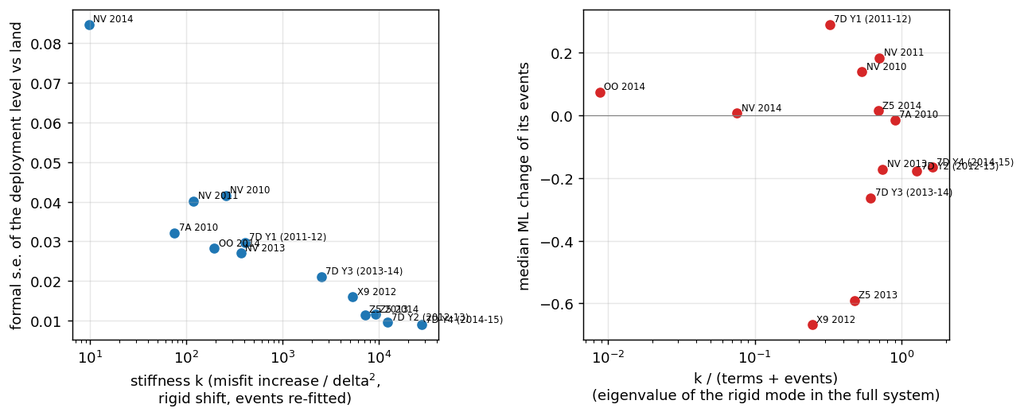

Left: formal standard error of each deployment level against its stiffness (v4.1). Right: median ML change of the events dominated by a deployment against the eigenvalue of its rigid mode in the full system; small values are the directions LSQR converges on last.

## 3. Catalog v4.1 (the paper's magnitudes)

New file `/wd1/mdenolle_data/magnitude_converged/v4.1/cascadia_catalog_M_routeA_converged.csv` (130,769 events, same columns and events as the stored `data/magnitude_v4/cascadia_catalog_M_routeA.csv`; the v4.1 patch is applied as in `utils/fix_catalog_v4.py`: 172113 removed, 900001-900003 copied from the stored file as ComCat Mw). Provenance: `.provenance.json` next to it (solver diagnostics of both passes, anchor offset and scatter, mapping fit, Mw_cal offsets, M_type counts, thread settings, MD5 of the stored and new files, git commit).

phase19 numbers, stored -> converged: anchor offset +0.413 -> +0.356; anchor scatter 0.211 -> 0.174; 'mapped' fit ML = -0.353 + 1.154 ML_inv (std 0.76) -> -0.295 + 1.014 ML_inv (std 0.60); Mw_cal offset (near) +0.04 -> +0.19, (mapped) +0.97 -> +1.42; M_type ML 130,652 / Mw 80 / Mw_cal 35 (v4.0 run) -> 130,660 / 80 / 27 (before the v4.1 patch). The near-event Mw_cal offset grows because the large offshore events now have lower ML.

### By region (converged minus stored ML, all events with ML)

| region | n | median | p25 | p75 | mean |
| --- | --- | --- | --- | --- | --- |
| Axial | 13,933 | 0.066 | 0.065 | 0.067 | 0.066 |
| Endeavour | 104 | -0.165 | -0.257 | 0.149 | -0.091 |
| Explorer | 1,325 | -0.056 | -0.213 | 0.012 | -0.085 |
| JdF ridge/plate | 1,523 | -0.284 | -0.391 | 0.062 | -0.228 |
| Blanco | 31,314 | -0.667 | -0.686 | -0.594 | -0.524 |
| Gorda | 8,136 | -0.190 | -0.213 | -0.185 | -0.221 |
| Mendocino | 18,115 | -0.189 | -0.191 | -0.188 | -0.191 |
| Offshore forearc | 11,728 | -0.186 | -0.189 | 0.018 | -0.113 |
| Puget/Georgia | 13,999 | 0.014 | 0.012 | 0.017 | 0.013 |
| Cascades | 16,602 | 0.007 | 0.006 | 0.009 | -0.004 |
| Other onshore | 13,987 | 0.005 | -0.177 | 0.008 | -0.053 |

### By region, near events (3 or more picks within 150 km; the D-B091 set)

| region | n | median | p25 | p75 | mean |
| --- | --- | --- | --- | --- | --- |
| Axial | 13,905 | 0.066 | 0.065 | 0.067 | 0.066 |
| Endeavour | 82 | 0.058 | -0.221 | 0.164 | -0.017 |
| Explorer | 857 | 0.007 | -0.053 | 0.028 | 0.003 |
| JdF ridge/plate | 1,376 | -0.293 | -0.402 | 0.063 | -0.222 |
| Blanco | 30,214 | -0.674 | -0.686 | -0.621 | -0.533 |
| Gorda | 7,434 | -0.190 | -0.197 | -0.184 | -0.217 |
| Mendocino | 17,776 | -0.189 | -0.191 | -0.188 | -0.190 |
| Offshore forearc | 11,378 | -0.186 | -0.189 | 0.019 | -0.110 |
| Puget/Georgia | 13,922 | 0.014 | 0.012 | 0.017 | 0.014 |
| Cascades | 16,543 | 0.007 | 0.006 | 0.009 | -0.004 |
| Other onshore | 13,762 | 0.005 | -0.173 | 0.008 | -0.050 |

### By region, mapped events

| region | n | median | p25 | p75 | mean |
| --- | --- | --- | --- | --- | --- |
| Axial | 28 | -0.281 | -0.307 | -0.235 | -0.265 |
| Endeavour | 22 | -0.307 | -0.511 | -0.288 | -0.364 |
| Explorer | 468 | -0.232 | -0.266 | -0.204 | -0.245 |
| JdF ridge/plate | 147 | -0.256 | -0.319 | -0.222 | -0.280 |
| Blanco | 1,100 | -0.295 | -0.337 | -0.245 | -0.292 |
| Gorda | 702 | -0.252 | -0.288 | -0.219 | -0.258 |
| Mendocino | 339 | -0.221 | -0.275 | -0.179 | -0.226 |
| Offshore forearc | 350 | -0.223 | -0.261 | -0.179 | -0.223 |
| Puget/Georgia | 77 | -0.140 | -0.175 | -0.079 | -0.136 |
| Cascades | 59 | -0.138 | -0.198 | -0.042 | -0.117 |
| Other onshore | 225 | -0.268 | -0.334 | -0.218 | -0.270 |

### Near events at onshore labels, north and south of 42 N

| part | n | median | p25 | p75 | mean |
| --- | --- | --- | --- | --- | --- |
| onshore labels, north of 42 N | 39,700 | 0.009 | 0.007 | 0.014 | 0.007 |
| onshore labels, south of 42 N (northern California) | 4,527 | -0.184 | -0.187 | -0.178 | -0.181 |

The onshore +0.01 holds north of 42 N only. South of 42 N (northern California) near events drop by -0.19, with the NC network level (section 2). The onshore box of the Mc maps changes b from 0.92 to 1.01 (section 6).

### By ML method

| ML_method_s | n | median | p25 | p75 | mean |
| --- | --- | --- | --- | --- | --- |
| mapped | 3,517 | -0.252 | -0.306 | -0.207 | -0.258 |
| near | 127,249 | -0.060 | -0.191 | 0.012 | -0.175 |

### By stored ML

| Mbin | n | median | p25 | p75 | mean |
| --- | --- | --- | --- | --- | --- |
| (-3, 0] | 4,357 | 0.009 | 0.007 | 0.066 | 0.025 |
| (0, 1] | 32,403 | 0.012 | 0.007 | 0.065 | 0.013 |
| (1, 2] | 63,115 | -0.185 | -0.191 | 0.008 | -0.170 |
| (2, 3] | 28,430 | -0.614 | -0.681 | -0.188 | -0.423 |
| (3, 4] | 2,230 | -0.364 | -0.638 | -0.186 | -0.368 |
| (4, 7] | 231 | -0.471 | -0.597 | -0.186 | -0.365 |

### By distance to the nearest station with an amplitude (v4 hypocentre)

| dbin | n | median | p25 | p75 | mean |
| --- | --- | --- | --- | --- | --- |
| (0, 10] | 27,234 | 0.020 | 0.006 | 0.066 | -0.057 |
| (10, 25] | 42,530 | -0.173 | -0.623 | 0.009 | -0.219 |
| (25, 50] | 45,054 | -0.188 | -0.195 | 0.002 | -0.220 |
| (50, 100] | 13,299 | -0.175 | -0.190 | 0.002 | -0.133 |
| (100, 150] | 1,434 | -0.191 | -0.231 | -0.173 | -0.178 |
| (150, 1000] | 1,215 | -0.299 | -0.349 | -0.260 | -0.309 |

The change follows the region (the deployment that records the event), not the magnitude or the distance as such: the M 2-3 bin moves most (-0.61) because it is dominated by Blanco events, and the 0-10 km bin least because it is dominated by onshore and Axial events.

### Internal check: median ML of near events by region and year

The ocean-bottom deployments change from year to year, so a deployment level that is off shows as a jump of the regional median between years. Blanco, stored: 2.23 (2012), 2.07 (2013), 2.12 (2014), 1.61 (2015, recorded by Z5 2014); converged: 1.55, 1.39, 1.62, 1.56. The 2012-2014 deployments (X9, Z5 2013, 7D Y2/Y3) were 0.5-0.7 too high relative to the 2015 one in the stored catalog; the converged levels remove the jump. Rows with at least 50 events.

| region | year | n | ML_stored | ML_converged | dML |
| --- | --- | --- | --- | --- | --- |
| Axial | 2,014 | 1,180 | 0.679 | 0.747 | 0.066 |
| Axial | 2,015 | 12,452 | 0.512 | 0.579 | 0.066 |
| Axial | 2,016 | 271 | 0.203 | 0.269 | 0.066 |
| Blanco | 2,012 | 4,510 | 2.231 | 1.551 | -0.686 |
| Blanco | 2,013 | 13,815 | 2.064 | 1.388 | -0.684 |
| Blanco | 2,014 | 7,559 | 2.127 | 1.618 | -0.633 |
| Blanco | 2,015 | 4,310 | 1.611 | 1.557 | -0.048 |
| Explorer | 2,012 | 208 | 2.044 | 2.124 | 0.064 |
| Explorer | 2,013 | 231 | 2.040 | 1.976 | -0.061 |
| Explorer | 2,014 | 356 | 2.045 | 2.038 | 0.005 |
| Gorda | 2,010 | 100 | 2.201 | 2.010 | -0.190 |
| Gorda | 2,011 | 105 | 2.144 | 1.953 | -0.189 |
| Gorda | 2,012 | 750 | 2.127 | 1.829 | -0.241 |
| Gorda | 2,013 | 1,076 | 2.145 | 1.844 | -0.256 |
| Gorda | 2,014 | 3,256 | 1.968 | 1.776 | -0.190 |
| Gorda | 2,015 | 2,147 | 1.767 | 1.590 | -0.184 |
| JdF ridge/plate | 2,012 | 186 | 1.509 | 1.823 | 0.274 |
| JdF ridge/plate | 2,013 | 488 | 2.043 | 1.607 | -0.373 |
| JdF ridge/plate | 2,014 | 383 | 2.007 | 1.644 | -0.325 |
| JdF ridge/plate | 2,015 | 284 | 1.641 | 1.700 | 0.064 |
| Mendocino | 2,010 | 2,166 | 1.604 | 1.415 | -0.189 |
| Mendocino | 2,011 | 1,902 | 1.541 | 1.353 | -0.189 |
| Mendocino | 2,012 | 2,960 | 1.483 | 1.293 | -0.190 |
| Mendocino | 2,013 | 2,522 | 1.597 | 1.407 | -0.190 |
| Mendocino | 2,014 | 3,600 | 1.473 | 1.284 | -0.189 |
| Mendocino | 2,015 | 4,624 | 1.399 | 1.210 | -0.189 |
| Offshore forearc | 2,010 | 1,690 | 1.772 | 1.621 | -0.189 |
| Offshore forearc | 2,011 | 1,242 | 1.619 | 1.528 | -0.033 |
| Offshore forearc | 2,012 | 1,687 | 1.456 | 1.378 | -0.145 |
| Offshore forearc | 2,013 | 1,507 | 1.388 | 1.322 | -0.076 |
| Offshore forearc | 2,014 | 2,736 | 1.396 | 1.268 | -0.187 |
| Offshore forearc | 2,015 | 2,446 | 1.361 | 1.256 | -0.186 |
| Offshore forearc | 2,016 | 70 | 1.907 | 1.823 | -0.114 |
| Puget/Georgia | 2,010 | 2,540 | 1.117 | 1.133 | 0.015 |
| Puget/Georgia | 2,011 | 1,748 | 1.119 | 1.134 | 0.014 |
| Puget/Georgia | 2,012 | 2,044 | 1.075 | 1.089 | 0.015 |
| Puget/Georgia | 2,013 | 1,993 | 1.068 | 1.083 | 0.014 |
| Puget/Georgia | 2,014 | 2,066 | 1.064 | 1.080 | 0.014 |
| Puget/Georgia | 2,015 | 2,278 | 1.046 | 1.061 | 0.014 |
| Puget/Georgia | 2,016 | 1,253 | 1.198 | 1.208 | 0.012 |

### M_type transitions (rows stored, columns converged)

| M_type_s | ML | Mw | Mw_cal |
| --- | --- | --- | --- |
| ML | 130,648 | 0 | 3 |
| Mw | 0 | 83 | 0 |
| Mw_cal | 11 | 0 | 24 |

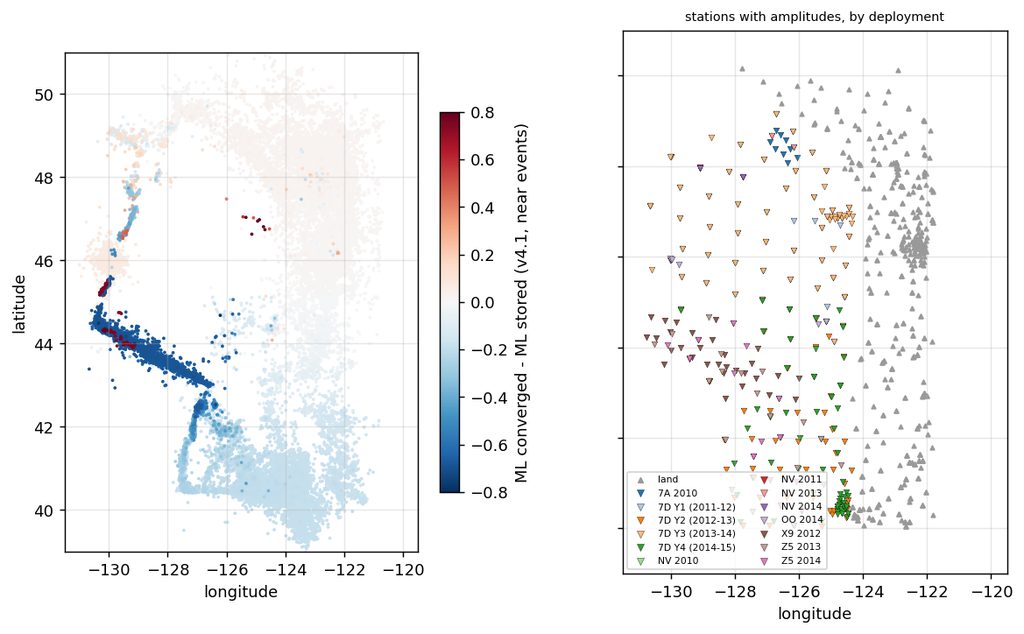

v4.1, converged minus stored ML (near events), and the stations with amplitudes by deployment.

## 4. External references and the D-B091 numbers

### ComCat ML anchors (median ML - ComCat ML, near events)

| solution | value | n | median | p25 | p75 | std |
| --- | --- | --- | --- | --- | --- | --- |
| v4.1 stored | offshore and coastal labels | 549.000 | 0.115 | -0.125 | 0.379 | 0.339 |
| v4.1 stored | onshore labels | 2867.000 | -0.007 | -0.088 | 0.081 | 0.166 |
| v4.1 stored | all | 3416.000 | 0.000 | -0.092 | 0.109 | 0.211 |
| v4.1 converged | offshore and coastal labels | 549.000 | 0.010 | -0.141 | 0.195 | 0.257 |
| v4.1 converged | onshore labels | 2867.000 | -0.001 | -0.080 | 0.083 | 0.153 |
| v4.1 converged | all | 3416.000 | 0.000 | -0.088 | 0.092 | 0.174 |
| v5.1 stored | offshore and coastal labels | 547.000 | 0.171 | -0.096 | 0.483 | 0.364 |
| v5.1 stored | onshore labels | 2867.000 | -0.009 | -0.091 | 0.084 | 0.176 |
| v5.1 stored | all | 3414.000 | 0.000 | -0.091 | 0.114 | 0.231 |
| v5.1 converged | offshore and coastal labels | 547.000 | 0.013 | -0.133 | 0.217 | 0.256 |
| v5.1 converged | onshore labels | 2867.000 | -0.001 | -0.081 | 0.081 | 0.154 |
| v5.1 converged | all | 3414.000 | 0.000 | -0.089 | 0.093 | 0.175 |

| value | v4.1 converged | v4.1 stored | v5.1 converged | v5.1 stored |
| --- | --- | --- | --- | --- |
| Axial | 0.937 | 0.875 | 0.913 | 0.969 |
| Blanco | 0.062 | 0.479 | 0.085 | 0.594 |
| Gorda | 0.020 | 0.239 | 0.011 | 0.329 |
| Mendocino | 0.268 | 0.459 | 0.258 | 0.539 |
| Offshore forearc | -0.045 | -0.037 | -0.043 | -0.019 |
| Puget/Georgia | -0.008 | -0.021 | -0.003 | -0.020 |
| Cascades | -0.013 | -0.015 | -0.013 | -0.019 |
| Other onshore | 0.043 | 0.047 | 0.028 | 0.034 |

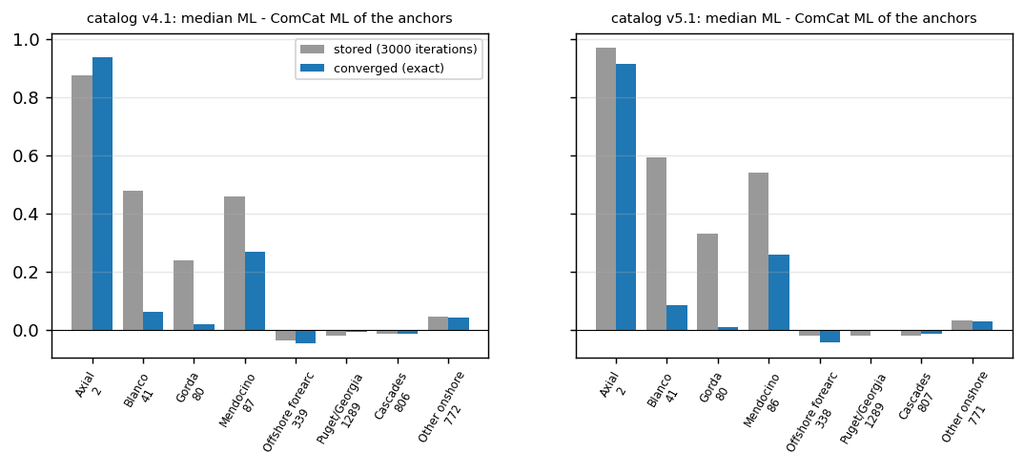

Median ML - ComCat ML of the anchors by region, stored and converged; the number under each label is the number of anchors.

### ComCat moment tensors (median ML - Mw)

| events | Mw_class | v4.1 converged | v4.1 stored | v5.1 converged | v5.1 stored |
| --- | --- | --- | --- | --- | --- |
| all | 3-4.5 | -0.151 | -0.022 | -0.112 | 0.076 |
| all | 3-4.5, offshore and coastal labels | -0.231 | -0.051 | -0.207 | 0.076 |
| all | 3-4.5, onshore labels | 0.073 | 0.045 | 0.087 | 0.074 |
| all | 4.5-5.5 | -1.150 | -0.793 | -1.222 | -0.798 |
| all | 5.5-7.5 | -1.200 | -1.014 | -1.309 | -0.944 |
| near | 3-4.5 | -0.024 | 0.083 | -0.012 | 0.222 |
| near | 3-4.5, offshore and coastal labels | -0.073 | 0.111 | -0.019 | 0.264 |
| near | 3-4.5, onshore labels | 0.080 | 0.054 | 0.119 | 0.106 |
| near | 4.5-5.5 | -0.691 | -0.357 | -0.665 | -0.199 |
| near | 5.5-7.5 | -0.795 | -0.676 | -0.755 | -0.464 |

| solution | events | Mw_class | n | ML_minus_Mw | ci95_lo | ci95_hi |
| --- | --- | --- | --- | --- | --- | --- |
| v4.1 stored | all | 3-4.5 | 67 | -0.022 | -0.090 | 0.111 |
| v4.1 stored | all | 4.5-5.5 | 60 | -0.793 | -1.076 | -0.553 |
| v4.1 stored | all | 5.5-7.5 | 20 | -1.014 | -1.155 | -0.623 |
| v4.1 stored | all | 3-4.5, offshore and coastal labels | 57 | -0.051 | -0.142 | 0.111 |
| v4.1 stored | all | 3-4.5, onshore labels | 10 | 0.045 | -0.050 | 0.493 |
| v4.1 stored | near | 3-4.5 | 52 | 0.083 | -0.022 | 0.197 |
| v4.1 stored | near | 4.5-5.5 | 29 | -0.357 | -0.755 | -0.197 |
| v4.1 stored | near | 5.5-7.5 | 9 | -0.676 | -1.144 | 0.010 |
| v4.1 stored | near | 3-4.5, offshore and coastal labels | 43 | 0.111 | -0.047 | 0.197 |
| v4.1 stored | near | 3-4.5, onshore labels | 9 | 0.054 | -0.050 | 0.526 |
| v4.1 converged | all | 3-4.5 | 67 | -0.151 | -0.265 | -0.015 |
| v4.1 converged | all | 4.5-5.5 | 60 | -1.150 | -1.401 | -0.915 |
| v4.1 converged | all | 5.5-7.5 | 20 | -1.200 | -1.618 | -0.943 |
| v4.1 converged | all | 3-4.5, offshore and coastal labels | 57 | -0.231 | -0.322 | -0.073 |
| v4.1 converged | all | 3-4.5, onshore labels | 10 | 0.073 | -0.042 | 0.310 |
| v4.1 converged | near | 3-4.5 | 52 | -0.024 | -0.143 | 0.064 |
| v4.1 converged | near | 4.5-5.5 | 29 | -0.691 | -0.946 | -0.386 |
| v4.1 converged | near | 5.5-7.5 | 9 | -0.795 | -1.131 | -0.172 |
| v4.1 converged | near | 3-4.5, offshore and coastal labels | 43 | -0.073 | -0.212 | 0.017 |
| v4.1 converged | near | 3-4.5, onshore labels | 9 | 0.080 | -0.042 | 0.335 |
| v5.1 stored | all | 3-4.5 | 64 | 0.076 | -0.009 | 0.267 |
| v5.1 stored | all | 4.5-5.5 | 56 | -0.798 | -0.982 | -0.506 |
| v5.1 stored | all | 5.5-7.5 | 19 | -0.944 | -1.034 | -0.464 |
| v5.1 stored | all | 3-4.5, offshore and coastal labels | 54 | 0.076 | -0.045 | 0.268 |
| v5.1 stored | all | 3-4.5, onshore labels | 10 | 0.074 | -0.059 | 0.405 |
| v5.1 stored | near | 3-4.5 | 52 | 0.222 | 0.066 | 0.286 |
| v5.1 stored | near | 4.5-5.5 | 27 | -0.199 | -0.682 | -0.086 |
| v5.1 stored | near | 5.5-7.5 | 9 | -0.464 | -1.034 | 0.110 |
| v5.1 stored | near | 3-4.5, offshore and coastal labels | 43 | 0.264 | 0.075 | 0.284 |
| v5.1 stored | near | 3-4.5, onshore labels | 9 | 0.106 | -0.034 | 0.617 |
| v5.1 converged | all | 3-4.5 | 64 | -0.112 | -0.243 | 0.001 |
| v5.1 converged | all | 4.5-5.5 | 56 | -1.222 | -1.513 | -0.973 |
| v5.1 converged | all | 5.5-7.5 | 19 | -1.309 | -1.714 | -1.012 |
| v5.1 converged | all | 3-4.5, offshore and coastal labels | 54 | -0.207 | -0.327 | -0.017 |
| v5.1 converged | all | 3-4.5, onshore labels | 10 | 0.087 | -0.042 | 0.288 |
| v5.1 converged | near | 3-4.5 | 52 | -0.012 | -0.141 | 0.055 |
| v5.1 converged | near | 4.5-5.5 | 27 | -0.665 | -0.920 | -0.370 |
| v5.1 converged | near | 5.5-7.5 | 9 | -0.755 | -1.132 | -0.173 |
| v5.1 converged | near | 3-4.5, offshore and coastal labels | 43 | -0.019 | -0.208 | 0.028 |
| v5.1 converged | near | 3-4.5, onshore labels | 9 | 0.119 | -0.016 | 0.334 |

### Tensor Mw 3-4.5, near events, by region (median ML - Mw)

| region | v4.1 converged | v4.1 stored | v5.1 converged | v5.1 stored | n_v41 |
| --- | --- | --- | --- | --- | --- |
| Blanco | -0.818 | -0.720 | -0.749 | -0.552 | 1 |
| Cascades | 0.013 | -0.006 | 0.019 | 0.004 | 4 |
| Explorer | -0.127 | -0.125 | -0.103 | -0.009 | 3 |
| Gorda | -0.223 | -0.035 | -0.225 | 0.067 | 10 |
| Mendocino | -0.052 | 0.132 | -0.018 | 0.265 | 20 |
| Offshore forearc | 0.017 | 0.197 | 0.009 | 0.284 | 9 |
| Other onshore | 0.310 | 0.493 | 0.288 | 0.405 | 5 |

The tensor comparison is inconclusive. For near events at offshore labels with Mw 3-4.5 (43 events), ML - Mw goes from +0.11 [-0.05, +0.20] to -0.07 [-0.21, +0.02] (v4.1; median and bootstrap 95% interval) and from +0.26 [+0.07, +0.28] to -0.02 [-0.21, +0.03] (v5.1). The intervals overlap, and by region Gorda gets worse (-0.03 -> -0.22, 10 events) while Mendocino and the offshore forearc get better. The tensors do not reject either solution; the ComCat ML anchors (549 offshore and coastal, 3,416 in all) are the stronger test. Onshore, ML - Mw stays at +0.05 to +0.12. Counted over all events, the offshore value goes to -0.21/-0.23 because of the 11-14 'mapped' tensor events: their ML comes from the Theil-Sen map of the inversion ML, whose slope fell from 1.15 to 1.01 when the near ML it is fitted to came down. phase19 already flags mapped ML above about 4 as lower bounds. Above Mw 4.5 the tensor Mw is used, so these values do not enter M.

### D-B091 on the stored pick sets

These comparisons use the stored system (stored pick set, isolated term included, two gauge rows), which is what the stored runs and the D-B091 check solved; its exact solution gives the same ML as the new one-row system (column max_abs_dML_exact_new_vs_stored_system). On the pick set of the stored v5.1 run, the exact solver reproduces the D-B091 changes, and the D-B091 LSQR to istop 2 (4,863 iterations) is within 0.006 of it in every region except Axial (-0.03); its largest event error is 0.18. On the v4.1 pick set (the stored per-pick table was not kept, so a 12-thread legacy rerun stands in) the same LSQR is within 0.02 except Axial (+0.06). The data misfit drops by 274 (v5.1, 0.38%) and 184 (v4.1, 0.25%) from the stored to the exact solution. Redoing the first pass and the 4-MAD rejection with the exact solver changes only tens of picks per deployment and the regional medians by at most 0.02 (columns full_chain_minus_stored and rejection_effect). The larger Explorer and Endeavour changes in the all-event region tables come from the 'mapped' events (Explorer: 485 of 1,326), not from the rejection.

| catalog | solution | system | max_abs_dML_exact_new_vs_stored_system | misfit | r_norm | itn | istop |
| --- | --- | --- | --- | --- | --- | --- | --- |
| v4.1 | 3000 iterations (rerun, 12 threads) | stored (two gauge rows, isolated term kept) | 0.002 | 72504.569 | 269.267 |  |  |
| v4.1 | D-B091 LSQR to istop 2 | stored (two gauge rows, isolated term kept) | 0.002 | 72321.076 | 268.926 | 4658.000 | 2.000 |
| v4.1 | exact | stored (two gauge rows, isolated term kept) | 0.002 | 72320.585 | 268.925 |  |  |
| v5.1 | 3000 iterations (stored) | stored (two gauge rows, isolated term kept) | 0.003 | 72021.387 | 268.368 |  |  |
| v5.1 | D-B091 LSQR to istop 2 | stored (two gauge rows, isolated term kept) | 0.003 | 71749.167 | 267.860 | 4863.000 | 2.000 |
| v5.1 | exact | stored (two gauge rows, isolated term kept) | 0.003 | 71747.892 | 267.858 |  |  |

| region | n | exact_minus_stored | db091_minus_stored | exact_minus_db091 | full_chain_minus_stored | rejection_effect | max_abs_exact_minus_db091 | catalog |
| --- | --- | --- | --- | --- | --- | --- | --- | --- |
| Axial | 13905.000 | 0.068 | 0.006 | 0.061 | 0.073 | 0.006 | 0.061 | v4.1 |
| Endeavour | 82.000 | 0.122 | 0.103 | 0.018 | 0.093 | 0.002 | 0.044 | v4.1 |
| Explorer | 858.000 | 0.013 | 0.015 | -0.001 | 0.014 | 0.002 | 0.032 | v4.1 |
| JdF ridge/plate | 1376.000 | -0.236 | -0.231 | -0.003 | -0.240 | -0.005 | 0.095 | v4.1 |
| Blanco | 30214.000 | -0.636 | -0.641 | 0.005 | -0.656 | -0.019 | 0.095 | v4.1 |
| Gorda | 7434.000 | -0.167 | -0.168 | 0.001 | -0.168 | -0.002 | 0.005 | v4.1 |
| Mendocino | 17776.000 | -0.167 | -0.168 | 0.001 | -0.168 | -0.002 | 0.002 | v4.1 |
| Offshore forearc | 11379.000 | -0.164 | -0.165 | 0.001 | -0.166 | -0.002 | 0.050 | v4.1 |
| Puget/Georgia | 13922.000 | 0.012 | 0.012 | -0.000 | 0.013 | 0.001 | 0.011 | v4.1 |
| Cascades | 16543.000 | 0.006 | 0.006 | -0.000 | 0.006 | 0.000 | 0.010 | v4.1 |
| Other onshore | 13762.000 | 0.004 | 0.004 | -0.000 | 0.004 | 0.000 | 0.061 | v4.1 |
| all | 127251.000 | -0.022 | -0.023 | 0.001 | -0.021 | 0.000 | 0.095 | v4.1 |
| Axial | 13756.000 | -0.067 | -0.036 | -0.031 | -0.060 | 0.007 | 0.031 | v5.1 |
| Endeavour | 82.000 | 0.102 | 0.104 | -0.002 | 0.086 | 0.002 | 0.053 | v5.1 |
| Explorer | 841.000 | -0.074 | -0.077 | 0.001 | -0.076 | -0.001 | 0.047 | v5.1 |
| JdF ridge/plate | 1367.000 | -0.512 | -0.507 | -0.006 | -0.510 | 0.002 | 0.173 | v5.1 |
| Blanco | 30356.000 | -0.682 | -0.683 | 0.001 | -0.701 | -0.018 | 0.178 | v5.1 |
| Gorda | 7440.000 | -0.285 | -0.281 | -0.004 | -0.288 | -0.003 | 0.019 | v5.1 |
| Mendocino | 17758.000 | -0.284 | -0.280 | -0.005 | -0.288 | -0.003 | 0.006 | v5.1 |
| Offshore forearc | 11392.000 | -0.282 | -0.277 | -0.004 | -0.285 | -0.003 | 0.132 | v5.1 |
| Puget/Georgia | 13895.000 | 0.015 | 0.015 | 0.001 | 0.015 | 0.000 | 0.009 | v5.1 |
| Cascades | 16423.000 | 0.015 | 0.015 | 0.001 | 0.015 | 0.000 | 0.013 | v5.1 |
| Other onshore | 13532.000 | 0.011 | 0.010 | 0.000 | 0.011 | 0.000 | 0.056 | v5.1 |
| all | 126842.000 | -0.183 | -0.196 | 0.000 | -0.178 | -0.000 | 0.178 | v5.1 |

v4.1: picks kept only by the stored chain or only by the exact chain, by deployment

| deployment | only_stored | only_exact | n_exact | catalog |
| --- | --- | --- | --- | --- |
| 7A 2010 | 0 | 1 | 188 | v4.1 |
| 7D Y1 (2011-12) | 1 | 3 | 2,368 | v4.1 |
| 7D Y2 (2012-13) | 13 | 11 | 32,962 | v4.1 |
| 7D Y3 (2013-14) | 12 | 7 | 7,819 | v4.1 |
| 7D Y4 (2014-15) | 7 | 7 | 68,583 | v4.1 |
| NV 2010 | 0 | 0 | 625 | v4.1 |
| NV 2011 | 0 | 0 | 210 | v4.1 |
| NV 2013 | 1 | 0 | 602 | v4.1 |
| NV 2014 | 0 | 0 | 189 | v4.1 |
| OO 2014 | 0 | 0 | 112,078 | v4.1 |
| X9 2012 | 5 | 2 | 121,591 | v4.1 |
| Z5 2013 | 4 | 11 | 55,439 | v4.1 |
| Z5 2014 | 9 | 1 | 36,387 | v4.1 |
| land | 30 | 36 | 925,155 | v4.1 |

v5.1: picks kept only by the stored chain or only by the exact chain, by deployment

| deployment | only_stored | only_exact | n_exact | catalog |
| --- | --- | --- | --- | --- |
| 7A 2010 | 0 | 2 | 167 | v5.1 |
| 7D Y1 (2011-12) | 0 | 4 | 2,401 | v5.1 |
| 7D Y2 (2012-13) | 4 | 8 | 33,037 | v5.1 |
| 7D Y3 (2013-14) | 10 | 15 | 7,818 | v5.1 |
| 7D Y4 (2014-15) | 6 | 11 | 68,690 | v5.1 |
| NV 2010 | 0 | 3 | 628 | v5.1 |
| NV 2011 | 0 | 0 | 211 | v5.1 |
| NV 2013 | 0 | 0 | 594 | v5.1 |
| NV 2014 | 0 | 0 | 199 | v5.1 |
| OO 2014 | 8 | 1 | 111,062 | v5.1 |
| X9 2012 | 2 | 10 | 122,024 | v5.1 |
| Z5 2013 | 4 | 7 | 55,562 | v5.1 |
| Z5 2014 | 3 | 3 | 36,393 | v5.1 |
| land | 40 | 46 | 918,149 | v5.1 |

## 5. Catalog v5.1

### By region (converged minus stored, all events with ML)

| region | n | median | p25 | p75 | mean |
| --- | --- | --- | --- | --- | --- |
| Axial | 13,788 | -0.060 | -0.061 | -0.059 | -0.061 |
| Endeavour | 104 | -0.347 | -0.459 | 0.153 | -0.186 |
| Explorer | 1,326 | -0.236 | -0.315 | -0.067 | -0.194 |
| JdF ridge/plate | 1,513 | -0.493 | -0.570 | -0.061 | -0.346 |
| Blanco | 31,399 | -0.697 | -0.711 | -0.655 | -0.580 |
| Gorda | 8,144 | -0.289 | -0.308 | -0.285 | -0.315 |
| Mendocino | 18,113 | -0.288 | -0.289 | -0.287 | -0.289 |
| Offshore forearc | 11,736 | -0.285 | -0.288 | 0.009 | -0.178 |
| Puget/Georgia | 13,976 | 0.015 | 0.014 | 0.016 | 0.014 |
| Cascades | 16,476 | 0.015 | 0.014 | 0.017 | -0.003 |
| Other onshore | 13,771 | 0.010 | -0.275 | 0.015 | -0.084 |

### By region, near events

| region | n | median | p25 | p75 | mean |
| --- | --- | --- | --- | --- | --- |
| Axial | 13,756 | -0.060 | -0.061 | -0.059 | -0.060 |
| Endeavour | 82 | 0.086 | -0.440 | 0.176 | -0.097 |
| Explorer | 841 | -0.076 | -0.220 | -0.044 | -0.106 |
| JdF ridge/plate | 1,367 | -0.510 | -0.583 | -0.060 | -0.341 |
| Blanco | 30,356 | -0.701 | -0.711 | -0.675 | -0.585 |
| Gorda | 7,440 | -0.288 | -0.294 | -0.284 | -0.311 |
| Mendocino | 17,757 | -0.288 | -0.289 | -0.287 | -0.288 |
| Offshore forearc | 11,391 | -0.285 | -0.288 | 0.009 | -0.174 |
| Puget/Georgia | 13,895 | 0.015 | 0.014 | 0.016 | 0.015 |
| Cascades | 16,423 | 0.015 | 0.014 | 0.017 | -0.003 |
| Other onshore | 13,532 | 0.011 | -0.272 | 0.015 | -0.079 |

### By region, mapped events

| region | n | median | p25 | p75 | mean |
| --- | --- | --- | --- | --- | --- |
| Axial | 32 | -0.386 | -0.434 | -0.340 | -0.381 |
| Endeavour | 22 | -0.452 | -0.691 | -0.398 | -0.516 |
| Explorer | 485 | -0.327 | -0.375 | -0.291 | -0.347 |
| JdF ridge/plate | 146 | -0.360 | -0.439 | -0.320 | -0.394 |
| Blanco | 1,043 | -0.414 | -0.465 | -0.350 | -0.411 |
| Gorda | 704 | -0.358 | -0.404 | -0.313 | -0.365 |
| Mendocino | 356 | -0.317 | -0.389 | -0.265 | -0.321 |
| Offshore forearc | 345 | -0.319 | -0.369 | -0.261 | -0.315 |
| Puget/Georgia | 81 | -0.211 | -0.254 | -0.152 | -0.208 |
| Cascades | 53 | -0.261 | -0.311 | -0.123 | -0.216 |
| Other onshore | 239 | -0.368 | -0.450 | -0.292 | -0.368 |

### By distance to the nearest station (v5.1)

| dbin | n | median | p25 | p75 | mean |
| --- | --- | --- | --- | --- | --- |
| (0, 10] | 45,581 | -0.059 | -0.285 | 0.015 | -0.128 |
| (10, 25] | 43,359 | -0.287 | -0.691 | 0.013 | -0.310 |
| (25, 50] | 30,168 | -0.285 | -0.490 | -0.058 | -0.293 |
| (50, 100] | 9,083 | -0.275 | -0.288 | -0.082 | -0.208 |
| (100, 150] | 1,196 | -0.289 | -0.352 | -0.273 | -0.281 |
| (150, 1000] | 959 | -0.429 | -0.494 | -0.379 | -0.443 |

### v5.1 minus v4.1, stored pair against converged pair (same events)

| region | n | d_stored | d_conv |
| --- | --- | --- | --- |
| Axial | 13786.000 | -0.112 | -0.239 |
| Endeavour | 103.000 | 0.135 | 0.024 |
| Explorer | 1317.000 | 0.105 | 0.002 |
| JdF ridge/plate | 1499.000 | 0.146 | 0.005 |
| Blanco | 31245.000 | 0.062 | 0.011 |
| Gorda | 8093.000 | 0.096 | 0.000 |
| Mendocino | 18068.000 | 0.092 | -0.006 |
| Offshore forearc | 11704.000 | 0.066 | -0.006 |
| Puget/Georgia | 13972.000 | 0.003 | 0.004 |
| Cascades | 16461.000 | 0.011 | 0.014 |
| Other onshore | 13755.000 | 0.015 | 0.004 |
| all | 130003.000 | 0.047 | 0.001 |
| offshore and coastal labels | 85815.000 | 0.070 | -0.004 |
| onshore labels | 44188.000 | 0.009 | 0.007 |

| Mbin | d_stored | d_conv |
| --- | --- | --- |
| (-3, 0] | 0.016 | 0.018 |
| (0, 1] | 0.007 | -0.002 |
| (1, 2] | 0.063 | 0.002 |
| (2, 3] | 0.083 | -0.001 |
| (3, 4] | 0.081 | -0.009 |
| (4, 7] | 0.098 | 0.001 |

With both catalogs converged, the relocation changes ML by +0.00 everywhere except Axial (-0.24). At Axial the stations are a few km from the events, so the depth change of the relocation moves the Hutton-Boore distance term. The +0.05 to +0.15 offshore changes of the stored pair came from the two unconverged runs stopping at different points.

### M_type transitions v5.1 (rows stored, columns converged)

| M_type_s | ML | Mw | Mw_cal | none |
| --- | --- | --- | --- | --- |
| ML | 130,231 | 0 | 1 | 0 |
| Mw | 0 | 84 | 0 | 0 |
| Mw_cal | 10 | 0 | 23 | 0 |
| none | 0 | 0 | 0 | 41,993 |

## 6. Mc and b

Same estimators, grid and boxes as the v5.1 magnitude piece (`workflow/06_analysis/v51_mc_b.py`, which imports `v4_mc_maps.py`: MAXC+0.2, MBS, GFT90/95, the Woessner & Wiemer best rule, 200 bootstrap resamples, Aki-Utsu b with the Shi & Bolt error). Versions: A = v4.1 M on the v4 epicentres (the paper's Mc), B = v4.1 M on the v5.1 epicentres, C = v5.1 M on the v5.1 epicentres; here all with converged M. Version A stored equals the paper's `data/catalog_v4/mc_maps/mc_regional.csv` (n 130,772 includes 3 duplicated rows of 900001-900003 from the v4.1 catalog join, as in the stored run).

| version | region | n_stored | mc_best_stored | mc_best_conv | d_mc_best | mc_maxc_stored | mc_maxc_conv | b_stored | b_conv | d_b |
| --- | --- | --- | --- | --- | --- | --- | --- | --- | --- | --- |
| A_v4M_v4loc | AX | 13,913 | 0.200 | 0.300 | 0.100 | 0.700 | 0.700 | 0.702 | 0.722 | 0.020 |
| A_v4M_v4loc | EN | 1,823 | 1.800 | 1.600 | -0.200 | 2.200 | 2.000 | 0.811 | 0.750 | -0.061 |
| A_v4M_v4loc | BL | 31,563 | 2.200 | 1.600 | -0.600 | 2.300 | 1.700 | 1.169 | 1.104 | -0.066 |
| A_v4M_v4loc | GO | 6,964 | 2.100 | 1.700 | -0.400 | 2.300 | 2.000 | 1.094 | 1.046 | -0.047 |
| A_v4M_v4loc | MT | 28,750 | 1.700 | 1.500 | -0.200 | 1.600 | 1.400 | 1.006 | 1.004 | -0.002 |
| A_v4M_v4loc | WA | 2,828 | 1.200 | 1.300 | 0.100 | 1.300 | 1.200 | 0.994 | 1.053 | 0.059 |
| A_v4M_v4loc | OR | 1,393 | 1.600 | 1.500 | -0.100 | 1.700 | 1.700 | 1.030 | 1.149 | 0.119 |
| A_v4M_v4loc | PU | 13,348 | 1.200 | 1.300 | 0.100 | 1.200 | 1.200 | 1.219 | 1.272 | 0.053 |
| A_v4M_v4loc | ON | 30,190 | 1.300 | 1.300 | 0.000 | 1.500 | 1.500 | 0.920 | 1.007 | 0.087 |
| A_v4M_v4loc | OFF | 44,571 | 2.200 | 1.700 | -0.500 | 2.300 | 1.700 | 1.147 | 1.089 | -0.059 |
| A_v4M_v4loc | ALL | 130,772 | 2.100 | 1.500 | -0.600 | 1.600 | 1.500 | 1.052 | 0.997 | -0.055 |
| B_v4M_v51loc | AX | 14,015 | 0.400 | 0.500 | 0.100 | 0.700 | 0.700 | 0.791 | 0.804 | 0.013 |
| B_v4M_v51loc | EN | 1,859 | 1.800 | 1.600 | -0.200 | 2.200 | 2.000 | 0.812 | 0.754 | -0.058 |
| B_v4M_v51loc | BL | 31,496 | 2.200 | 1.600 | -0.600 | 2.300 | 1.700 | 1.177 | 1.112 | -0.066 |
| B_v4M_v51loc | GO | 7,075 | 2.100 | 1.900 | -0.200 | 2.300 | 2.000 | 1.093 | 1.210 | 0.117 |
| B_v4M_v51loc | MT | 28,626 | 1.700 | 1.500 | -0.200 | 1.600 | 1.400 | 1.010 | 1.007 | -0.002 |
| B_v4M_v51loc | WA | 2,763 | 1.200 | 1.300 | 0.100 | 1.300 | 1.200 | 0.997 | 1.057 | 0.060 |
| B_v4M_v51loc | OR | 1,242 | 1.600 | 1.600 | 0.000 | 1.800 | 1.700 | 0.967 | 1.164 | 0.197 |
| B_v4M_v51loc | PU | 13,049 | 1.200 | 1.200 | 0.000 | 1.200 | 1.200 | 1.235 | 1.227 | -0.008 |
| B_v4M_v51loc | ON | 26,874 | 1.300 | 1.300 | 0.000 | 1.500 | 1.500 | 0.851 | 0.941 | 0.090 |
| B_v4M_v51loc | OFF | 44,435 | 2.200 | 1.700 | -0.500 | 2.300 | 1.700 | 1.152 | 1.090 | -0.062 |
| B_v4M_v51loc | ALL | 126,999 | 2.100 | 1.500 | -0.600 | 1.500 | 1.500 | 1.054 | 0.985 | -0.069 |
| C_v51M_v51loc | AX | 13,866 | 0.200 | 0.100 | -0.100 | 0.500 | 0.500 | 0.715 | 0.700 | -0.014 |
| C_v51M_v51loc | EN | 1,874 | 1.900 | 1.600 | -0.300 | 2.200 | 2.000 | 0.797 | 0.744 | -0.052 |
| C_v51M_v51loc | BL | 31,609 | 2.300 | 1.600 | -0.700 | 2.400 | 1.700 | 1.209 | 1.116 | -0.093 |
| C_v51M_v51loc | GO | 7,106 | 2.200 | 1.900 | -0.300 | 2.300 | 2.100 | 1.103 | 1.220 | 0.117 |
| C_v51M_v51loc | MT | 28,658 | 1.700 | 1.500 | -0.200 | 1.700 | 1.400 | 0.975 | 1.008 | 0.033 |
| C_v51M_v51loc | WA | 2,773 | 1.200 | 1.300 | 0.100 | 1.200 | 1.200 | 0.998 | 1.056 | 0.057 |
| C_v51M_v51loc | OR | 1,248 | 1.600 | 1.500 | -0.100 | 1.800 | 1.700 | 0.891 | 1.066 | 0.175 |
| C_v51M_v51loc | PU | 13,044 | 1.200 | 1.200 | 0.000 | 1.200 | 1.200 | 1.222 | 1.210 | -0.012 |
| C_v51M_v51loc | ON | 26,891 | 1.200 | 1.200 | 0.000 | 0.700 | 1.500 | 0.742 | 0.857 | 0.116 |
| C_v51M_v51loc | OFF | 44,610 | 2.200 | 1.700 | -0.500 | 2.400 | 1.700 | 1.124 | 1.090 | -0.034 |
| C_v51M_v51loc | ALL | 127,069 | 2.100 | 1.500 | -0.600 | 1.700 | 1.500 | 1.026 | 0.977 | -0.048 |
| C_qc | AX | 11,935 | 0.200 | 0.100 | -0.100 | 0.500 | 0.500 | 0.723 | 0.708 | -0.015 |
| C_qc | EN | 951 | 2.000 | 1.800 | -0.200 | 2.200 | 2.000 | 0.764 | 0.717 | -0.047 |
| C_qc | BL | 19,608 | 2.300 | 1.700 | -0.600 | 2.400 | 1.800 | 1.160 | 1.098 | -0.062 |
| C_qc | GO | 4,412 | 2.200 | 1.900 | -0.300 | 2.400 | 2.100 | 1.049 | 1.152 | 0.103 |
| C_qc | MT | 22,616 | 1.800 | 1.500 | -0.300 | 1.700 | 1.500 | 0.970 | 0.966 | -0.004 |
| C_qc | WA | 1,840 | 1.200 | 1.300 | 0.100 | 1.400 | 1.300 | 1.036 | 1.074 | 0.038 |
| C_qc | OR | 634 | 1.500 | 1.500 | 0.000 | 1.700 | 1.800 | 0.803 | 0.991 | 0.188 |
| C_qc | PU | 8,873 | 1.200 | 1.200 | 0.000 | 1.200 | 1.300 | 1.188 | 1.175 | -0.014 |
| C_qc | ON | 15,413 | 1.200 | 1.200 | 0.000 | 0.800 | 0.800 | 0.868 | 0.976 | 0.107 |
| C_qc | OFF | 27,445 | 2.300 | 1.800 | -0.500 | 2.400 | 1.800 | 1.131 | 1.075 | -0.055 |
| C_qc | ALL | 86,282 | 2.200 | 1.600 | -0.600 | 1.700 | 1.500 | 1.039 | 0.978 | -0.061 |

### Version A by period, offshore boxes

| region | period | n_stored | mc_best_stored | mc_best_conv | b_stored | b_conv |
| --- | --- | --- | --- | --- | --- | --- |
| EN | 2010 | 52 |  |  |  |  |
| BL | 2010 | 78 |  |  |  |  |
| GO | 2010 | 185 | 2.200 | 1.800 | 0.840 | 0.793 |
| MT | 2010 | 3,852 | 1.800 | 1.600 | 0.996 | 0.987 |
| OFF | 2010 | 826 | 2.000 | 1.600 | 0.586 | 0.618 |
| EN | 2011-2012 | 599 | 1.900 | 1.700 | 0.967 | 0.856 |
| BL | 2011-2012 | 5,051 | 2.600 | 1.500 | 1.256 | 0.863 |
| GO | 2011-2012 | 1,210 | 2.100 | 1.900 | 1.019 | 1.163 |
| MT | 2011-2012 | 7,286 | 1.600 | 1.400 | 0.986 | 0.976 |
| OFF | 2011-2012 | 8,092 | 2.500 | 1.700 | 1.188 | 0.948 |
| EN | 2013-2015 | 1,140 | 1.800 | 1.600 | 0.850 | 0.768 |
| BL | 2013-2015 | 26,293 | 2.200 | 1.600 | 1.276 | 1.216 |
| GO | 2013-2015 | 5,520 | 2.100 | 1.900 | 1.212 | 1.323 |
| MT | 2013-2015 | 17,554 | 1.700 | 1.500 | 1.028 | 1.027 |
| OFF | 2013-2015 | 35,246 | 2.200 | 1.700 | 1.253 | 1.200 |
| EN | 2016 | 32 |  |  |  |  |
| BL | 2016 | 141 | 2.400 | 2.100 | 0.646 | 0.715 |
| GO | 2016 | 49 |  |  |  |  |
| MT | 2016 | 58 |  |  |  |  |
| OFF | 2016 | 407 | 2.500 | 1.800 | 0.588 | 0.558 |

### Paired b test, converged v5.1 M against converged v4.1 M (same events, common Mc)

| box | mc_source | mc | n_events | b_v41 | b_v51 | db | sd_paired | z | significant_bonferroni |
| --- | --- | --- | --- | --- | --- | --- | --- | --- | --- |
| AX | Mc_best C | 0.100 | 13,865 | 0.595 | 0.700 | 0.105 | 0.003 | 30.931 | True |
| AX | Mc_best B | 0.500 | 13,865 | 0.801 | 0.746 | -0.056 | 0.006 | -9.491 | True |
| EN | Mc_best C | 1.600 | 1,856 | 0.754 | 0.741 | -0.013 | 0.005 | -2.751 | False |
| BL | Mc_best C | 1.600 | 31,454 | 1.114 | 1.117 | 0.002 | 0.003 | 0.920 | False |
| GO | Mc_best C | 1.900 | 7,056 | 1.208 | 1.217 | 0.009 | 0.007 | 1.204 | False |
| MT | Mc_best C | 1.500 | 28,593 | 1.004 | 1.005 | 0.000 | 0.002 | 0.168 | False |
| WA | Mc_best C | 1.300 | 2,762 | 1.056 | 1.054 | -0.002 | 0.009 | -0.181 | False |
| OR | Mc_best C | 1.500 | 1,241 | 1.092 | 1.065 | -0.028 | 0.016 | -1.682 | False |
| OR | Mc_best B | 1.600 | 1,241 | 1.166 | 1.096 | -0.070 | 0.022 | -3.132 | True |
| PU | Mc_best C | 1.200 | 13,041 | 1.227 | 1.210 | -0.017 | 0.005 | -3.624 | True |
| ON | Mc_best C | 1.200 | 26,858 | 0.878 | 0.857 | -0.021 | 0.003 | -7.935 | True |
| ON | Mc_best B | 1.300 | 26,858 | 0.939 | 0.901 | -0.039 | 0.004 | -11.145 | True |
| OFF | Mc_best C | 1.700 | 44,369 | 1.088 | 1.087 | -0.001 | 0.002 | -0.485 | False |
| ALL | Mc_best C | 1.500 | 126,726 | 0.982 | 0.974 | -0.008 | 0.001 | -6.199 | True |
| ON without MSH | Mc_best C | 1.200 | 17,041 | 0.889 | 0.890 | 0.001 | 0.002 | 0.355 | False |
| ON without MSH | Mc_best B | 1.300 | 17,041 | 0.952 | 0.941 | -0.011 | 0.003 | -3.790 | True |
| MSH only | Mc_best C | 0.000 | 9,817 | 0.739 | 0.720 | -0.020 | 0.003 | -6.379 | True |

Offshore Mc drops by 0.2-0.6 with the magnitudes. With the paper's script (v4_mc_maps.py, `mc_maps_v41/mc_regional.csv`): Blanco 2.2 -> 1.6, Gorda 2.1 -> 1.9, Mendocino triple junction 1.7 -> 1.5, Endeavour-Explorer 1.8 -> 1.6, offshore pooled 2.2 -> 1.7. The Gorda value is borderline: GFT95 is reached at 1.9 there, but not in version A of v51_mc_b.py (the same events plus 3 duplicated rows of 900001-900003), which falls back to GFT90 = 1.7 with b 1.05 instead of 1.22. Onshore Mc does not change. Two period statements of the paper change. The Blanco Mc of 2011-2012 (2.6 stored) was inflated by the same deployment levels: converged it is 1.5, against 1.6 in 2013-2015, so the 'offshore Mc improved by 0.2-0.4 after the first two years' result does not hold (EN +0.1, BL -0.1, GO 0.0). The rate of M >= 2.5 Blanco events in 2010 and 2016, relative to 2013-2015, rises from 5% and 8% to 28% and 29%: the events of the ocean-bottom years came down by 0.6-0.7, those of 2010 and 2016 (mapped, land stations only) by about 0.3. The Mendocino 2016 ratio stays at 10-11%. b changes by -0.07 to +0.12 in the offshore boxes. In the onshore box (everything outside the named boxes) b goes from 0.92 to 1.01 although its median ML change is +0.01: 11% of its events drop by more than 0.1, half of them in northern California between 40 and 42 N (east of the triple-junction box, recorded by the Gorda and Mendocino ocean-bottom stations) and 12% of them 'mapped' events. Between converged v5.1 and converged v4.1 M (paired test, same events) b agrees within 0.03 in every box except Axial (+0.10 at Mc 0.1, the Axial relocation).

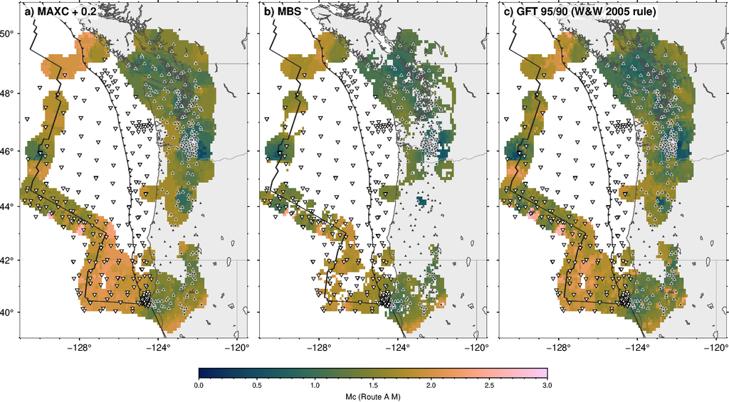

Paper Fig. 2a remade: Mc by three methods, converged v4.1 M (v4 epicentres).

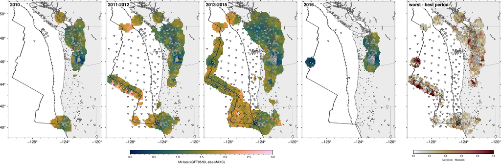

Paper Fig. 2b remade: Mc best by period, converged v4.1 M.

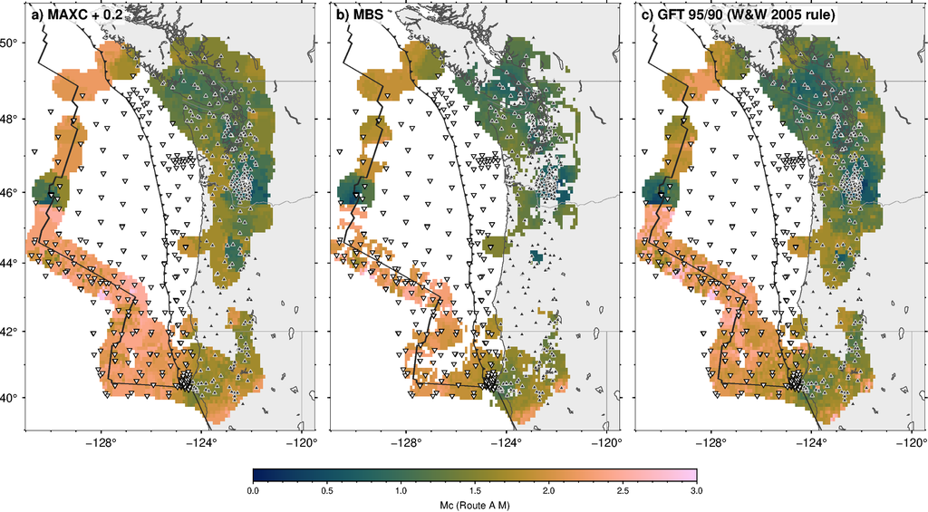

Paper Fig. 2a as it is now (stored M), for comparison.

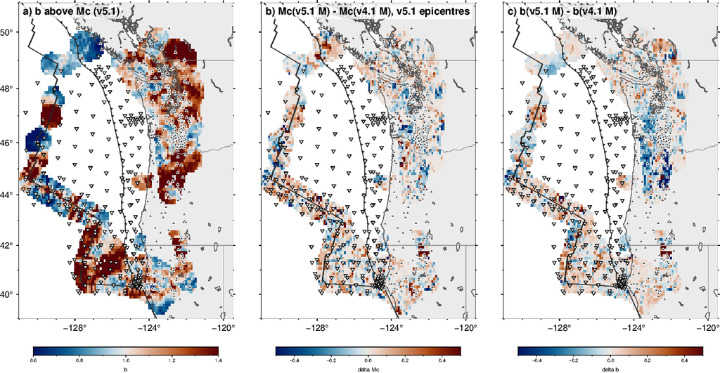

v5.1 converged: b above Mc and the change of Mc and b between converged v5.1 and converged v4.1 M on the v5.1 epicentres.

## 7. Paper impact

Every figure, table and number of the paper (Overleaf `sciadv/main.tex` and `supplementary.tex` at 8def2ea4b5, the repository copies on main, and the figure scripts) that uses Route A M, with the stored and the converged value or the figure to remake. The manuscript is not edited (manuscript changes are bullets only, by the PI). Clustering values: `v4_clusters_zbz.py` rerun on the converged v4.1 M (main run and 3 shuffles, no sensitivity variants) in `/wd1/mdenolle_data/magnitude_converged/clusters_zbz_v41`.

| location | item | stored | converged | action |
| --- | --- | --- | --- | --- |
| main.tex 77-78; Text S5 (supp 174-181); Methods 435-450 | ComCat anchors and scatter | 3,416 anchors, scatter 0.21 | 3,416 anchors, scatter 0.17 (offset +0.413 -> +0.356) | update |
| main.tex 77-78; Text S5 | events with a magnitude | 130,769 (main) / 130,767 (Text S5) | 130,769 (unchanged) | unchanged; Text S5 should say 130,769 (v4.1) |
| Methods 435-450 (not in text) | M_type counts (v4.0 run, before patch) | ML 130,652 / Mw 80 / Mw_cal 35 | ML 130,660 / Mw 80 / Mw_cal 27 | update if quoted (v4.1 adds 3 Mw) |
| not in text (D-B041 input) | Mw_cal offset (near / mapped) | +0.04 / +0.97 | +0.19 / +1.42 | note |
| not in text (driver.log; D-B041) | ML - tensor Mw, all events: Mw 3-4.5 / 4.5-5.5 / 5.5-7.5 | -0.02 / -0.79 / -1.01 | -0.15 / -1.15 / -1.20 | note (near events only: +0.08 -> -0.02 at Mw 3-4.5) |
| main.tex 429 (Overleaf bullet) | matched moment tensors used for the ML-Mw check | 112 (catalog v3 count) | 147 (v4.1) | fix the count |
| main.tex 79-84 | pooled Mc: onshore and forearc (WA, PU, ON, OR, MT) | 1.2-1.7 (1.2, 1.2, 1.3, 1.6, 1.7) | 1.3-1.5 (1.3, 1.3, 1.3, 1.5, 1.5) | update |
| main.tex 79-84 | pooled Mc: offshore plate boundaries (EN, GO, BL) | 1.8-2.2 (1.8, 2.1, 2.2) | 1.6-1.9 (1.6, 1.9, 1.6) | update |
| main.tex 79-84 | offshore pooled Mc (OFF) / all | 2.2 / 2.1 | 1.7 / 1.5 | note |
| main.tex 85-91 | Blanco Mc_best 2011-2012 -> 2013-2015 | 2.6 -> 2.2 | 1.5 -> 1.6 | update |
| main.tex 85-91 | offshore Mc improvement 2011-12 -> 2013-15 (EN, BL, GO) | +0.1, +0.4, +0.0 | +0.1, -0.1, +0.0 | update |
| main.tex 85-93 | rate of M >= 2.5, BL 2010 / 2013-2015 | 0.05 | 0.28 | update (absolute threshold) |
| main.tex 85-93 | rate of M >= 2.5, BL 2016 / 2013-2015 | 0.08 | 0.29 | update (absolute threshold) |
| main.tex 85-93 | rate of M >= 2.5, MT 2016 / 2013-2015 | 0.10 | 0.11 | update (absolute threshold) |
| Text S7 (supp 241-259) | Axial pooled: GFT sigma; MAXC; node 10-90% | sigma 0.94; MAXC 0.7; nodes 0.4-1.0 | sigma 0.63; MAXC 0.7; nodes 0.4-1.2 | update |
| main.tex 79-84 | node medians, Puget Lowland and offshore Washington (PU, WA) | 1.1, 1.0 | 1.2, 1.1 | update |
| main.tex 79-84 | highest nodes (western Blanco, northern Gorda) | max 3.2; GO max 2.8 | max 2.8 (western Blanco); GO max 2.4 | rewrite: 'highest on the western Blanco transform (2.7-2.8)' |
| main.tex 79-84 | lowest nodes (Mount St. Helens, Axial) | ON min -0.2, AX min 0.2 | ON min -0.2, AX min 0.3 | check (0.0-0.3 holds) |
| Text S7 | MAXC+0.2 most conservative (share of nodes); MBS - MAXC; best - MAXC (same criterion both) | 89%; -0.19; -0.20 (text: 84%, -0.19, -0.14) | 88%; -0.19; -0.18 | update (text criterion may differ: compare in the same way) |
| Text S7 | QC-only minus all, Mc_best per node | median 0.0, IQR +-0.1 | median 0.0, IQR +-0.1 | unchanged |
| paper_sciadv/figures | Fig. 2a | fig2a_mc_three_methods.png | /wd1/mdenolle_data/magnitude_converged/mc_maps_v41/fig1_mc_three_methods.png | replace (remade with v4_mc_maps.py on the converged v4.1 M) |
| paper_sciadv/figures | Fig. 2b | fig2b_mc_periods.png | /wd1/mdenolle_data/magnitude_converged/mc_maps_v41/fig3_mc_periods.png | replace (remade with v4_mc_maps.py on the converged v4.1 M) |
| supplementary Figs. S3-S7 | mc_maps fig1-fig5 | data/catalog_v4/mc_maps/fig*.png | /wd1/mdenolle_data/magnitude_converged/mc_maps_v41/fig*.png | replace (fig4_regional_fmd still draws the stored clustering Mc line: rerun after the clustering) |
| Table S6 | Mc / b / rate-ratio table | data/catalog_v4/mc_maps/mc_regional.csv | /wd1/mdenolle_data/magnitude_converged/mc_maps_v41/mc_regional.csv | replace |
| Fig. 1 A; Fig. 3 B-D; perspective_mendocino_fault.png | symbol size by M (msize = 0.012 x 2.2^(M-1)) | stored M | converged M: Blanco symbols about 1.7x smaller in diameter, JdF 1.3x, Gorda/Mendocino 1.2x | remake (workflow/08_figures/v4_figures.py reads the Route A file from its own repo root) |
| Fig. 4 | Blanco strands | loads M, does not use it | - | no change |
| Fig. S8 (catalog comparison), Fig. 7, Figs. S1-S2 | - | no Route A M | - | no change |
| main.tex 384-385; Text S6 | events kept by the per-region Mc | 27,555 | 27,423 | update |
| Text S6 | clustering Mc range (per region, MAXC+0.2, largest yearly) | 0.75-2.45 | 0.85-2.25 | update |
| Table S5; Fig. 5 | clustering Mc per region | AX 0.75; EN 2.25; BL 2.45; GO 2.45; MT 1.85; WA 1.65; OR 1.85; PU 1.35; ON 1.75 | AX 0.85; EN 2.25; BL 1.75; GO 2.25; MT 1.85; WA 1.65; OR 1.85; PU 1.35; ON 1.65 | update |
| Table S5; Fig. 5 | analysis-set events per region | AX 4,290; EN 512; BL 6,133; GO 1,150; MT 7,690; WA 412; OR 389; PU 3,245; ON 3,734 | AX 4,004; EN 421; BL 9,055; GO 931; MT 4,741; WA 428; OR 318; PU 3,345; ON 4,180 | update |
| main.tex 234-243 | background share AX, BL, GO ('about half') | 50.6, 50.2, 60.8 | 51.6, 49.8, 62.5 | update |
| main.tex 234-243 | families >= 5 that are swarms, AX, BL, GO ('two thirds') | 60.6, 66.0, 65.4 | 60.7, 62.8, 55.0 | update |
| main.tex 234-243 | Mendocino triple junction: swarm share of families >= 5; events Mc+1..2 without offspring | 30.6%; 75.7% | 27.6%; 73.6% | update |
| main.tex 234-243 | background share WA, OR, PU, ON ('68-84%') | 84.2, 68.4, 79.0, 69.4 | 82.5, 66.7, 78.7, 70.0 | update |
| main.tex 245-250 | Blanco swarms: duration and extent ('4 hours', '4 km') | 62 BL swarms, median duration90 4.0 h, extent 3.9 km | 91 BL swarms, median duration90 4.0 h, extent 4.6 km | update |
| main.tex 245-250, 341-343 | swarm share on West Blanco / Surveyor / Cascadia Depression strands ('33-45%') | swarm % of events above Mc: BL004a 45.0; BL006a 34.6; BL015a 34.5; BL011b 35.0; BL012 32.9 | swarm % of events above Mc: BL004a 44.8; BL006a 28.1; BL015a 42.2; BL011b 33.3; BL012 27.8 | update |
| main.tex 258-265 (Overleaf); Fig. 6A | Axial weekly events above Mc and swarm families per month (text: about 60 -> about 300 per week, 1,021 in the eruption week, below 15 per week within four weeks) | Nov 2014 39/wk, mid-Mar 2015 314/wk; eruption week 1,024 (calendar week, Mon-Sun; the text's quantity) or 999 (7-day bins of Fig. 6A); next four 7-day bins [45, 11, 4, 2]; swarm families Nov 2014 1, M… | Nov 2014 36/wk, mid-Mar 2015 285/wk; eruption week 998 (calendar week, Mon-Sun; the text's quantity) or 975 (7-day bins of Fig. 6A); next four 7-day bins [41, 5, 4, 1]; swarm families Nov 2014 1, Mar … | update |
| main.tex 224-232, 245-250, 270-275; Text S6 | validation families (IDs renumber) | June 2015 Blanco family: id 1803, swarm, n 77 (above Mc), n_all 755 \| Axial eruption family: id 1758, swarm, n 632 (above Mc), n_all 805 \| 2012 Blanco Mw 5.8/6.0 family: id 270, swarm, n 77 (above M… | June 2015 Blanco family: id 1797, swarm, n 277 (above Mc), n_all 850 \| Axial eruption family: id 1750, swarm, n 601 (above Mc), n_all 762 \| 2012 Blanco Mw 5.8/6.0 family: id 259, swarm, n 115 (above… | update |
| main.tex 224-232; Text S6 | six large earthquakes are mainshock-aftershock; eruption is one swarm | 2010-01-10 Mw 6.5 Gorda mainshock-aftershock; 2014-03-10 Mw 6.8 Gorda mainshock-aftershock; 2011-09-09 Mw 6.4 Vancou mainshock-aftershock; 2014-04-24 Mw 6.5 Vancou mainshock-aftershock; 2012-11-08 Mw … | 2010-01-10 Mw 6.5 Gorda mainshock-aftershock; 2014-03-10 Mw 6.8 Gorda mainshock-aftershock; 2011-09-09 Mw 6.4 Vancou mainshock-aftershock; 2014-04-24 Mw 6.5 Vancou mainshock-aftershock; 2012-11-08 Mw … | check |
| Text S6 | bimodality (Ashman D) real; shuffled | 1.62-3.42; 0.30-1.61 | 1.72-2.93; 0.38-1.29 | update |
| Text S6 | shuffled events below the real threshold (frac_below_eta0, mean of 3 shuffles) | AX 36%; BL 22%; EN 26%; GO 13%; MT 25%; ON 9%; OR 20%; PU 9%; WA 8% | AX 35%; BL 26%; EN 20%; GO 18%; MT 24%; ON 11%; OR 21%; PU 10%; WA 10% | update (text: 3-17%, Axial 34%) |
| Text S7 | regions where the clustering Mc is below one of the three map methods | BL (MBS 2.5 > 2.45) | AX (0.85 vs MAXC 0.7, MBS 1.5, best 0.3), BL (1.75 vs MAXC 1.7, MBS 1.8, best 1.6), PU (1.35 vs MAXC 1.2, MBS 1.4, best 1.3) | update |
| Figs. 5, 6; Table S5; family IDs 270, 346, 1758, 1803 | clustering products | data/catalog_v4/clusters_zbz | /wd1/mdenolle_data/magnitude_converged/clusters_zbz_v41 | regenerate figures (v4_figures.py clusters/short) and re-identify the family IDs quoted in the text |
| Overleaf main.tex 265 (repo main.tex 243) | '... to almost none above Mc 0.75' (Axial clustering Mc) | 0.75 | 0.85 | update |
| Overleaf main.tex 435-438 (repo main.tex 405-408), Methods | 'inverted for event size, distance attenuation and station terms' | wrong for the near-event ML (127,000 of 130,769 events): the Hutton-Boore distance term is fixed, only event and station-phase terms are inverted; the solver is not mentioned | near ML: event + station-phase terms with the Hutton & Boore (1987) distance term fixed, solved exactly (one gauge row); the distance-attenuation inversion (phase3) is used only for the 3,522 'mapped'… | correct the Methods sentence (bullet) |
| Fig. 6B (West Blanco swarm, June 2015) | symbols coloured and sized by M (cpt 1.5-5.0); stars 'M x.x' for M >= 5 | stored M | converged M: the ML events of the swarm drop by about 0.67; the three tensor Mw (5.80, 5.44, 5.89) do not change | remake (colour bar range may need 1.0-5.0) |
| main.tex 291-294 (Fig. 6D) | 'only events near the coast or above M 4 remain' | stored M | Mendocino ML -0.19 (v4.1 near) | recheck on the remade Fig. 6D |
| main.tex 352-363 | 'the magnitude scale ... the same everywhere' | claim | holds better: offshore anchor gap +0.12 -> +0.01 | keep; cite the converged solver in Methods |
| Overleaf main.tex 126 | comparison with Zhang & Niksejel 2025 (offshore Mc 1.5) | ours 1.8-2.2 | ours 1.6-1.9 (EN 1.6, BL 1.6, GO 1.9 pooled) | update the comparison |
| Table S4 rows GO004, GO011 | catalog maximum M | M5.6, M4.1 (catalog magnitude column, not Route A) | Route A: 144373 Mw 5.45; 103612 ML 3.85 -> see per-event file | check (not Route A values) |
| Text S5 | Hutton-Boore named without \cite | - | Hutton1987 is in references.bib | cite |
| workflow/06_analysis/v51_clusters_zbz.py:86, :90 (main) | v5.1 clustering reads the stored v5.1 magnitudes (MAG = /wd1/.../v5.1_analysis/mag/cascadia_catalog_v5.1_magnitudes.csv) and the stored mc_b table (MCB) | stored | converged: /wd1/mdenolle_data/magnitude_converged/v5.1/cascadia_catalog_v5.1_magnitudes_converged.csv; data/magnitude_converged/mc_b/mc_b_regional.csv | repoint and rerun (PR body) |
| workflow/06_analysis/v51_struct_common.py:29 (main) | v5.1 structure analysis MAG | stored v5.1 magnitudes | converged v5.1 table | repoint and rerun (PR body) |
| workflow/06_analysis/v51_interp_common.py:21, :81 (main) | v5.1 interpretation reads cascadia_catalog_v5.1_magnitudes_slim.csv.gz from V51_MAG (default the old worktree wt_a51_mag) | stored slim table | data/catalog_v5/v5.1_analysis/mag/cascadia_catalog_v5.1_magnitudes_converged_slim.csv.gz (new name, next to the stored one) | repoint and rerun (PR body) |
| workflow/10_tomography/params.yaml catalog_versions.v4_1_magnitudes (main) | catalog v5.x bundles take M from the v4.1 Route A file | data/magnitude_v4/cascadia_catalog_M_routeA.csv (main checkout) | /wd1/mdenolle_data/magnitude_converged/v4.1/cascadia_catalog_M_routeA_converged.csv | switch when adopted (PR body) |
| Data availability; atlas; catalog v5 bundles; Zenodo | Route A magnitudes in the released products | stored | converged | rebuild when the PI adopts the converged file (not done here) |

## 8. Files, reproduction, open problems

Code (branch analysis/mag-converged): `workflow/05_magnitude/phase19_solver.py` (new), `phase19_preferred_magnitude.py` (solver, --solver/--outdir/--tag, provenance), `v51_magnitude_table.py` (--pm/--out/--tag/--solver/--v4-mags), `mag_converged.py` (patch, near, threads, gauge, compare, reconcile, mcb), `mag_converged_report.py` and `mag_converged_text.py` (this page), `scale/run_magnitude_converged.sh` (driver). Resume notes: `/wd1/mdenolle_data/magnitude_converged/RESUME.md`.